# Wrangle LSC-R data

NOTE: Prior to cleaning in R, ages of events were cleaned as follows to reflect age of onsent (raw data files remain saved on mooddata):

- Use the earliest age of the event as the value. For example, if a participant reported witnessing an accident at ages 5, 10, 24 years, the age value is “5”.
- If participant reported a range of ages (e.g., 10-15), use the earliest age.
- If participant reported “all my life” or “all of childhood”, the age value is “0”.

# Environment set up

```r
#Libraries
library(tidyverse)
library(psych)
library(lubridate)
#Parameters
stress_ratings_cs_file1 <- "~/Desktop/BABIES/lena_symptoms/data/cs6_LSCR_2018-11_12_18_rated_n76_cleaned.xlsx"
stress_ratings_cs_file2 <- "~/Desktop/BABIES/lena_symptoms/data/cs6_LSCR_2019-04_08_19_rated_clean.xlsx"
stress_ratings_long_file <- "~/Desktop/BABIES/lena_symptoms/data/long_preg_LSCR_2018-10-01_rated.xlsx"
dates_file <- "~/Desktop/BABIES/lena_symptoms/data/demo_lscr_20190412.csv"
#Functions
source("~/Desktop/BABIES/lena_symptoms/lena_18mo_symptoms/winsorize.R")
```

```r
dates <-
  read_csv(dates_file) %>%
  mutate(
    baby_conception_date = baby_due_date - weeks(40),
    mom_age_conception = (mom_dob %--% baby_conception_date) / years(1),
    mom_age_babydob = (mom_dob %--% baby_dob) / years(1),
    mom_age_preg_visit = (mom_dob %--% preg_date) / years(1),
    mom_age_6mo_visit = (mom_dob %--% sixmonth_date) / years(1)
  )
```

# LSC-R Longitudinal: T1 (pregnancy)

## Read in T1 data

```r
lscr_preg <-
  readxl::read_xlsx(stress_ratings_long_file) %>%
  rename(ID = record_id) %>%
  mutate_at(
    vars(contains("preg"), "ID"),
    as.integer
  ) %>%
  mutate_at(
    vars(contains("Sev")),
    as.double
  ) %>%
  left_join(
    dates %>%
      select(
        ID,
        baby_due_date,
        mom_age_conception,
        mom_age_babydob
      ),
    by = "ID"
  )
```

```
-
/
```

## Calculate T1 reliability

```r
lscr_lk <-
  lscr_preg %>%
  select(
    ID,
    contains("sev_lk")
  ) %>%
  gather(variable, rater1, sev_lk_disas:sev_lk_other2) %>%
  mutate(
    variable = str_replace(variable, "lk_", "")
  ) %>%
  na.omit()
lscr_ls <-
  lscr_preg %>%
  select(
    ID,
    contains("sev_ls")
  ) %>%
  gather(variable, rater2, sev_ls_disas:sev_ls_other2) %>%
  mutate(
    variable = str_replace(variable, "ls_", "")
  ) %>%
  na.omit()
lscr_icc <-
  lscr_lk %>%
  left_join(lscr_ls, by = c("ID", "variable")) %>%
  select(-ID, -variable)
ICC(lscr_icc)
```

```
boundary (singular) fit: see ?isSingular
```

```
Call: ICC(x = lscr_icc)

Intraclass correlation coefficients
```

|  | type | ICC | F | df1 | df2 | p | lower bound | upper bound |
| --- | --- | --- | --- | --- | --- | --- | --- | --- |
| Single_raters_absolute | ICC1 | 0.9629877 | 53.03607 | 387 | 388 | 2.952617e-223 | 0.9550034 | 0.9695781 |
| Single_random_raters | ICC2 | 0.9629877 | 53.03607 | 387 | 387 | 9.497590e-223 | 0.9550034 | 0.9695781 |
| Single_fixed_raters | ICC3 | 0.9629877 | 53.03607 | 387 | 387 | 9.497590e-223 | 0.9549971 | 0.9695816 |
| Average_raters_absolute | ICC1k | 0.9811449 | 53.03607 | 387 | 388 | 2.952617e-223 | 0.9769839 | 0.9845541 |
| Average_random_raters | ICC2k | 0.9811449 | 53.03607 | 387 | 387 | 9.497590e-223 | 0.9769839 | 0.9845541 |
| Average_fixed_raters | ICC3k | 0.9811449 | 53.03607 | 387 | 387 | 9.497590e-223 | 0.9769806 | 0.9845559 |

```
 Number of subjects = 388     Number of Judges =  2
```

## Calculate T1 total scores

Total number of types, summed severity, max severity, total numer of pregnancy stressors, pregnancy summed severity, pregnancy max severity

```r
calc_preg_sev <- function(preg_exp, sev) { #pregnancy
  case_when(
    preg_exp == 1 ~ sev,
    TRUE ~ NA_real_
  )
}
#save variable names in order to map later
preg_exp_vars <-
  lscr_preg %>%
  select(contains("preg")) %>%
  names()
exp_vars <-
  lscr_preg %>%
  select(contains("preg")) %>%
  names() %>%
  str_replace("_preg", "")
sev_vars <-
  lscr_preg %>%
  select(contains("sev_con")) %>%
  names()
#add total scores: n lifetime, objective severity lifetime, n pregnancy
lscr_preg <-
  lscr_preg %>%
  mutate_at(
    vars(exp_vars),
    as.integer
  ) %>%
  mutate_at(
    vars(preg_exp_vars),
    as.integer
  ) %>%
  mutate(
    num_stress_total =
      pmap_int(
        select(., exp_vars),
        function(...) sum(c(...), na.rm = TRUE)
      ),
    num_stress_preg =
      pmap_int(
        select(., preg_exp_vars),
        function(...) sum(c(...), na.rm = TRUE)
      ),
    sum_sev =
      pmap_dbl(
        select(., sev_vars),
        function(...) sum(c(...), na.rm = TRUE)
      ),
    max_sev =
      pmap_dbl(
        select(., sev_vars),
        function(...) max(c(...), na.rm = TRUE)
      ),
    pregnancy_stress =
      if_else(
        num_stress_preg > 0,
        "yes", "no"
      )
  ) %>%
  mutate(
    max_sev = if_else(
      max_sev == -Inf,
      0, max_sev
    ),
    ##objective severity ratings during pregnancy
    sev_preg_disas = calc_preg_sev(lscr_disas_preg, sev_con_disas),
    sev_preg_witacc = calc_preg_sev(lscr_witacc_preg, sev_con_witacc),
    sev_preg_acc = calc_preg_sev(lscr_acc_preg, sev_con_acc),
    sev_preg_famjail = calc_preg_sev(lscr_famjail_preg, sev_con_famjail),
    sev_preg_jail = calc_preg_sev(lscr_jail_preg, sev_con_jail),
    sev_preg_adopt = calc_preg_sev(lscr_adopt_preg, sev_con_adopt),
    sev_preg_pardivorce = calc_preg_sev(lscr_pardivorce_preg, sev_con_pardivorce),
    sev_preg_divorce = calc_preg_sev(lscr_divorce_preg, sev_con_divorce),
    sev_preg_money = calc_preg_sev(lscr_money_preg, sev_con_money),
    sev_preg_ill = calc_preg_sev(lscr_ill_preg, sev_con_ill),
    sev_preg_emoab = calc_preg_sev(lscr_emoab_preg, sev_con_emoab),
    sev_preg_emoab_2 = calc_preg_sev(lscr_emoab_preg_2, sev_con_emoab2),
    sev_preg_physneg = calc_preg_sev(lscr_physneg_preg, sev_con_physneg),
    sev_preg_abort = calc_preg_sev(lscr_abort_preg, sev_con_abort),
    sev_preg_sepchild = calc_preg_sev(lscr_sepchild_preg, sev_con_sepchild),
    sev_preg_care = calc_preg_sev(lscr_care_preg, sev_con_care),
    sev_preg_death1 = calc_preg_sev(lscr_death1_preg, sev_con_death1),
    sev_preg_death2 = calc_preg_sev(lscr_death2_preg, sev_con_death2),
    sev_preg_famviol = calc_preg_sev(lscr_famviol_preg, sev_con_famviol),
    sev_preg_witmug = calc_preg_sev(lscr_witmug_preg, sev_con_witmug),
    sev_preg_mug = calc_preg_sev(lscr_mug_preg, sev_con_mug),
    sev_preg_physab = calc_preg_sev(lscr_physab_preg, sev_con_physab),
    sev_preg_domviol = calc_preg_sev(lscr_domviol_preg, sev_con_domviol),
    sev_preg_sexharas = calc_preg_sev(lscr_sexharas_preg, sev_con_sexharas),
    sev_preg_sextouch1 = calc_preg_sev(lscr_sextouch1_preg, sev_con_sextouch1),
    sev_preg_sextouch2 = calc_preg_sev(lscr_sextouch2_preg, sev_con_sextouch2),
    sev_preg_rape1 = calc_preg_sev(lscr_rape1_preg, sev_con_rape1),
    sev_preg_rape2 = calc_preg_sev(lscr_rape2_preg, sev_con_rape2),
    sev_preg_other1 = calc_preg_sev(lscr_other1_preg, sev_con_other1),
    sev_preg_other2 = calc_preg_sev(lscr_other2_preg, sev_con_other2)
  )
#save variable names to map over
preg_sev_vars <-
  lscr_preg %>%
  select(starts_with("sev_preg")) %>%
  names()
#calculate pregnancy objective severity
lscr_preg <-
  lscr_preg %>%
  mutate(
    sum_sev_preg =
      pmap_dbl(
        select(., preg_sev_vars),
        function(...) sum(c(...), na.rm = TRUE)
      ),
    max_sev_preg =
      pmap_dbl(
        select(., preg_sev_vars),
        function(...) max(c(...), na.rm = TRUE)
      ),
    max_sev_preg = if_else(
      max_sev_preg == -Inf,
      0, max_sev_preg
    )
  )
```

## T1 stress by developmental stage

get frequencies of each type in childhood vs. adulthood and separate sum sev get frequencies of childhood maltreatment and sum sev

```r
calc_dev_stage <- function(type_age) { #childhood vs. adulthood
  case_when(
    type_age <= 18 ~ "childhood",
    type_age > 18 ~ "adulthood",
    TRUE ~ NA_character_
  )
}
calc_sev_childhood <- function(dev_stage, sev) { #childhood
   if_else(
    dev_stage == "childhood",
    sev, NA_real_
  )
}
age_vars <-
  lscr_preg %>%
  select(contains("_age")) %>%
  names()
lscr_preg <-
  lscr_preg %>%
  mutate_at(
    vars(age_vars),
    .funs = funs("devstage" = calc_dev_stage(.))
  ) %>%
  mutate(
    ##objective ratings of stress in childhood
    sev_child_disas = calc_sev_childhood(lscr_disas_age_devstage, sev_con_disas),
    sev_child_witacc = calc_sev_childhood(lscr_witacc_age_devstage, sev_con_witacc),
    sev_child_acc = calc_sev_childhood(lscr_acc_age_devstage, sev_con_acc),
    sev_child_famjail = calc_sev_childhood(lscr_famjail_age_devstage, sev_con_famjail),
    sev_child_jail = calc_sev_childhood(lscr_jail_age_devstage, sev_con_jail),
    sev_child_adopt = calc_sev_childhood(lscr_adopt_age_devstage, sev_con_adopt),
    sev_child_pardivorce = calc_sev_childhood(lscr_pardivorce_age_devstage, sev_con_pardivorce),
    sev_child_divorce = calc_sev_childhood(lscr_divorce_age_devstage, sev_con_divorce),
    sev_child_money = calc_sev_childhood(lscr_money_age_devstage, sev_con_money),
    sev_child_ill = calc_sev_childhood(lscr_ill_age_devstage, sev_con_ill),
    sev_child_emoab = calc_sev_childhood(lscr_emoab_age_devstage, sev_con_emoab),
    sev_child_emoab_2 = calc_sev_childhood(lscr_emoab_age_2_devstage, sev_con_emoab2),
    sev_child_physneg = calc_sev_childhood(lscr_physneg_age_devstage, sev_con_physneg),
    sev_child_abort = calc_sev_childhood(lscr_abort_age_devstage, sev_con_abort),
    sev_child_sepchild = calc_sev_childhood(lscr_sepchild_age_devstage, sev_con_sepchild),
    sev_child_care = calc_sev_childhood(lscr_care_age_devstage, sev_con_care),
    sev_child_death1 = calc_sev_childhood(lscr_death1_age_devstage, sev_con_death1),
    sev_child_death2 = calc_sev_childhood(lscr_death2_age_devstage, sev_con_death2),
    sev_child_famviol = calc_sev_childhood(lscr_famviol_age_devstage, sev_con_famviol),
    sev_child_witmug = calc_sev_childhood(lscr_witmug_age_devstage, sev_con_witmug),
    sev_child_mug = calc_sev_childhood(lscr_mug_age_devstage, sev_con_mug),
    sev_child_physab = calc_sev_childhood(lscr_physab_age_devstage, sev_con_physab),
    sev_child_domviol = calc_sev_childhood(lscr_domviol_age_devstage, sev_con_domviol),
    sev_child_sexharas = calc_sev_childhood(lscr_sexharas_age_devstage, sev_con_sexharas),
    sev_child_sextouch1 = calc_sev_childhood(lscr_sextouch1_age_devstage, sev_con_sextouch1),
    sev_child_sextouch2 = calc_sev_childhood(lscr_sextouch2_age_devstage, sev_con_sextouch2),
    sev_child_rape1 = calc_sev_childhood(lscr_rape1_age_devstage, sev_con_rape1),
    sev_child_rape2 = calc_sev_childhood(lscr_rape2_age_devstage, sev_con_rape2),
    sev_child_other1 = calc_sev_childhood(lscr_other1_age_devstage, sev_con_other1),
    sev_child_other2 = calc_sev_childhood(lscr_other2_age_devstage, sev_con_other2)
  )
child_sev_vars <-
  lscr_preg %>%
  select(contains("sev_child")) %>%
  names()
lscr_preg <-
  lscr_preg %>%
  mutate(
    sum_sev_childhood =
      pmap_dbl(
        select(., child_sev_vars),
        function(...) sum(c(...), na.rm = TRUE)
      ),
    max_sev_childhood =
      pmap_dbl(
        select(., child_sev_vars),
        function(...) max(c(...), na.rm = TRUE)
      ),
    max_sev_childhood = if_else(
      max_sev_childhood == -Inf,
      0, max_sev_childhood
    ),
    sum_sev_maltreatment =
      pmap_dbl(
        select(
          .,
          sev_child_emoab,
          sev_child_emoab_2,
          sev_child_physab,
          sev_child_physneg,
          sev_child_adopt,
          sev_child_rape1,
          sev_child_rape2,
          sev_child_sextouch1,
          sev_child_sextouch2,
          sev_child_sexharas
        ),
        function(...) sum(c(...), na.rm = TRUE)
      ),
    maltreated = if_else(
      sum_sev_maltreatment > 0,
      "maltreated", "not maltreated"
    )
  )
```

## T1 stress by life stage in correspondance to pregnancy: preconception, postnatal

NOTE! life stages are based on when stressors STARTED. Some stressors started prior to conception but are coded as happening in pregnancy because they extended into pregnancy. There is no postnatal stress measured at T1 because T1 is during pregnancy.

### identify life stage for each report

```r
calc_preg_life_stage <- function(
  type_age, type_preg, mom_age_conception, mom_age_babydob
) {
  type_age = case_when(
    type_age <= mom_age_conception &
      (type_preg == 0 | is.na(type_preg)) ~ "preconception",
    type_preg == 1 ~ "pregnancy",
    type_age >= mom_age_babydob &
      (type_preg == 0 | is.na(type_preg)) ~ "postnatal"
  )
}
#identify life stages for each stressor
lscr_preg <-
  lscr_preg %>%
  mutate(
    lscr_disas_lifestage = calc_preg_life_stage(
      lscr_disas_age, lscr_disas_preg, mom_age_conception, mom_age_babydob
    ),
    lscr_witacc_lifestage = calc_preg_life_stage(
      lscr_witacc_age, lscr_witacc_preg, mom_age_conception, mom_age_babydob
    ),
    lscr_acc_lifestage = calc_preg_life_stage(
      lscr_acc_age, lscr_acc_preg, mom_age_conception, mom_age_babydob
    ),
    lscr_famjail_lifestage = calc_preg_life_stage(
      lscr_famjail_age, lscr_famjail_preg, mom_age_conception, mom_age_babydob
    ),
    lscr_jail_lifestage = calc_preg_life_stage(
      lscr_jail_age, lscr_jail_preg, mom_age_conception, mom_age_babydob
    ),
    lscr_adopt_lifestage = calc_preg_life_stage(
      lscr_adopt_age, lscr_adopt_preg, mom_age_conception, mom_age_babydob
    ),
    lscr_pardivorce_lifestage = calc_preg_life_stage(
      lscr_pardivorce_age, lscr_pardivorce_preg, mom_age_conception, mom_age_babydob
    ),
    lscr_divorce_lifestage = calc_preg_life_stage(
      lscr_divorce_age, lscr_divorce_preg, mom_age_conception, mom_age_babydob
    ),
    lscr_money_lifestage = calc_preg_life_stage(
      lscr_money_age, lscr_money_preg, mom_age_conception, mom_age_babydob
    ),
    lscr_ill_lifestage = calc_preg_life_stage(
      lscr_ill_age, lscr_ill_preg, mom_age_conception, mom_age_babydob
    ),
    lscr_emoab_lifestage = calc_preg_life_stage(
      lscr_emoab_age, lscr_emoab_preg, mom_age_conception, mom_age_babydob
    ),
    lscr_emoab2_lifestage = calc_preg_life_stage(
      lscr_emoab_age_2, lscr_emoab_preg_2, mom_age_conception, mom_age_babydob
    ),
    lscr_physneg_lifestage = calc_preg_life_stage(
      lscr_physneg_age, lscr_physneg_preg, mom_age_conception, mom_age_babydob
    ),
    lscr_abort_lifestage = calc_preg_life_stage(
      lscr_abort_age, lscr_abort_preg, mom_age_conception, mom_age_babydob
    ),
    lscr_abort_lifestage = calc_preg_life_stage(
      lscr_abort_age, lscr_abort_preg, mom_age_conception, mom_age_babydob
    ),
    lscr_sepchild_lifestage = calc_preg_life_stage(
      lscr_sepchild_age, lscr_sepchild_preg, mom_age_conception, mom_age_babydob
    ),
    lscr_care_lifestage = calc_preg_life_stage(
      lscr_care_age, lscr_care_preg, mom_age_conception, mom_age_babydob
    ),
    lscr_death1_lifestage = calc_preg_life_stage(
      lscr_death1_age, lscr_death1_preg, mom_age_conception, mom_age_babydob
    ),
    lscr_death2_lifestage = calc_preg_life_stage(
      lscr_death2_age, lscr_death2_preg, mom_age_conception, mom_age_babydob
    ),
    lscr_famviol_lifestage = calc_preg_life_stage(
      lscr_famviol_age, lscr_famviol_preg, mom_age_conception, mom_age_babydob
    ),
    lscr_witmug_lifestage = calc_preg_life_stage(
      lscr_witmug_age, lscr_witmug_preg, mom_age_conception, mom_age_babydob
    ),
    lscr_mug_lifestage = calc_preg_life_stage(
      lscr_mug_age, lscr_mug_preg, mom_age_conception, mom_age_babydob
    ),
    lscr_physab_lifestage = calc_preg_life_stage(
      lscr_physab_age, lscr_physab_preg, mom_age_conception, mom_age_babydob
    ),
    lscr_domviol_lifestage = calc_preg_life_stage(
      lscr_domviol_age, lscr_domviol_preg, mom_age_conception, mom_age_babydob
    ),
    lscr_sexharas_lifestage = calc_preg_life_stage(
      lscr_sexharas_age, lscr_sexharas_preg, mom_age_conception, mom_age_babydob
    ),
    lscr_sextouch1_lifestage = calc_preg_life_stage(
      lscr_sextouch1_age, lscr_sextouch1_preg, mom_age_conception, mom_age_babydob
    ),
    lscr_sextouch2_lifestage = calc_preg_life_stage(
      lscr_sextouch2_age, lscr_sextouch2_preg, mom_age_conception, mom_age_babydob
    ),
    lscr_rape1_lifestage = calc_preg_life_stage(
      lscr_rape1_age, lscr_rape1_preg, mom_age_conception, mom_age_babydob
    ),
    lscr_rape2_lifestage = calc_preg_life_stage(
      lscr_rape2_age, lscr_rape2_preg, mom_age_conception, mom_age_babydob
    ),
    lscr_other1_lifestage = calc_preg_life_stage(
      lscr_other1_age, lscr_other1_preg, mom_age_conception, mom_age_babydob
    ),
    lscr_other2_lifestage = calc_preg_life_stage(
      lscr_other2_age, lscr_other2_preg, mom_age_conception, mom_age_babydob
    )
  )
```

## calculate severity of preconception stressors

```r
calc_sev_preconception <- function(life_stage, sev) {
   case_when(
    life_stage == "preconception" ~ sev,
    TRUE ~ NA_real_
  )
}

#calculate severity for preconception stress
lscr_preg <-
  lscr_preg %>%
  mutate(
    #objective preconception severity ratings
    sev_precon_disas = calc_sev_preconception(lscr_disas_lifestage, sev_con_disas),
    sev_precon_witacc = calc_sev_preconception(lscr_witacc_lifestage, sev_con_witacc),
    sev_precon_acc = calc_sev_preconception(lscr_acc_lifestage, sev_con_acc),
    sev_precon_famjail = calc_sev_preconception(lscr_famjail_lifestage, sev_con_famjail),
    sev_precon_jail = calc_sev_preconception(lscr_jail_lifestage, sev_con_jail),
    sev_precon_adopt = calc_sev_preconception(lscr_adopt_lifestage, sev_con_adopt),
    sev_precon_pardivorce = calc_sev_preconception(lscr_pardivorce_lifestage, sev_con_pardivorce),
    sev_precon_divorce = calc_sev_preconception(lscr_divorce_lifestage, sev_con_divorce),
    sev_precon_money = calc_sev_preconception(lscr_money_lifestage, sev_con_money),
    sev_precon_ill = calc_sev_preconception(lscr_ill_lifestage, sev_con_ill),
    sev_precon_emoab = calc_sev_preconception(lscr_emoab_lifestage, sev_con_emoab),
    sev_precon_emoab_2 = calc_sev_preconception(lscr_emoab2_lifestage, sev_con_emoab2),
    sev_precon_physneg = calc_sev_preconception(lscr_physneg_lifestage, sev_con_physneg),
    sev_precon_abort = calc_sev_preconception(lscr_abort_lifestage, sev_con_abort),
    sev_precon_sep = calc_sev_preconception(lscr_sepchild_lifestage, sev_con_sepchild),
    sev_precon_care = calc_sev_preconception(lscr_care_lifestage, sev_con_care),
    sev_precon_death1 = calc_sev_preconception(lscr_death1_lifestage, sev_con_death1),
    sev_precon_death2 = calc_sev_preconception(lscr_death2_lifestage, sev_con_death2),
    sev_precon_famviol = calc_sev_preconception(lscr_famviol_lifestage, sev_con_famviol),
    sev_precon_witmug = calc_sev_preconception(lscr_witmug_lifestage, sev_con_witmug),
    sev_precon_mug = calc_sev_preconception(lscr_mug_lifestage, sev_con_mug),
    sev_precon_physab = calc_sev_preconception(lscr_physab_lifestage, sev_con_physab),
    sev_precon_domviol = calc_sev_preconception(lscr_domviol_lifestage, sev_con_domviol),
    sev_precon_sexharas = calc_sev_preconception(lscr_sexharas_lifestage, sev_con_sexharas),
    sev_precon_sextouch1 = calc_sev_preconception(lscr_sextouch1_lifestage, sev_con_sextouch1),
    sev_precon_sextouch2 = calc_sev_preconception(lscr_sextouch2_lifestage, sev_con_sextouch2),
    sev_precon_rape1 = calc_sev_preconception(lscr_rape1_lifestage, sev_con_rape1),
    sev_precon_rape2 = calc_sev_preconception(lscr_rape2_lifestage, sev_con_rape2),
    sev_precon_other1 = calc_sev_preconception(lscr_other1_lifestage, sev_con_other1),
    sev_precon_other2 = calc_sev_preconception(lscr_other2_lifestage, sev_con_other2)
  )
precon_sev_vars <-
  lscr_preg %>%
  select(contains("sev_precon")) %>%
  names()
lscr_preg <-
  lscr_preg %>%
  mutate(
    sum_sev_precon =
      pmap_dbl(
        select(., precon_sev_vars),
        function(...) sum(c(...), na.rm = TRUE)
      ),
    max_sev_precon =
      pmap_dbl(
        select(., precon_sev_vars),
        function(...) max(c(...), na.rm = TRUE)
      ),
    max_sev_precon = if_else(
      max_sev_precon == -Inf,
      0, max_sev_precon
    )
  )
```

## Examine T1 distributions

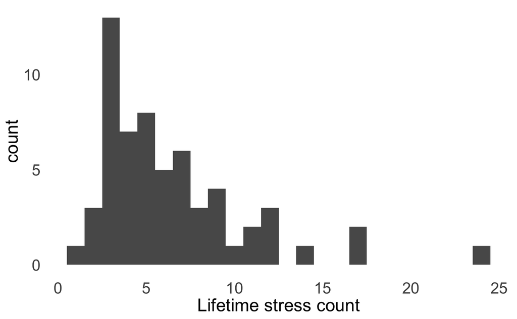

```r
lscr_preg %>%
  ggplot(aes(num_stress_total)) +
  geom_histogram(binwidth = 1) +
  scale_x_continuous(breaks = seq.int(0, 30, 5)) +
  theme_minimal() +
  theme(
    panel.grid = element_blank(),
    plot.title = element_text(size = 20, hjust = .5),
    axis.title = element_text(size = 18),
    axis.text = element_text(size = 16),
    legend.title = element_text(size = 18),
    legend.text = element_text(size = 16)
  ) +
  labs(
    x = "Lifetime stress count"
  )
```

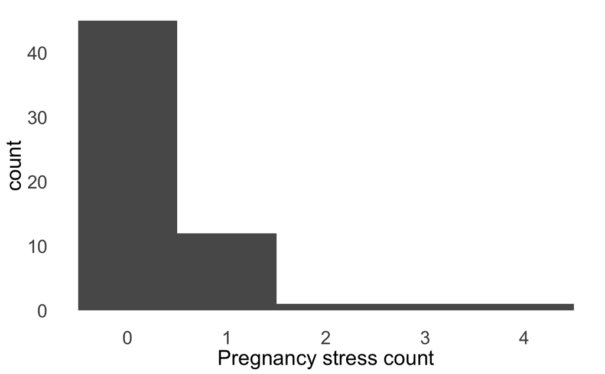

```r
lscr_preg %>%
  ggplot(aes(num_stress_preg)) +
  geom_histogram(binwidth = 1) +
  scale_x_continuous(breaks = seq.int(0, 30, 1)) +
  theme_minimal() +
  theme(
    panel.grid = element_blank(),
    plot.title = element_text(size = 20, hjust = .5),
    axis.title = element_text(size = 18),
    axis.text = element_text(size = 16),
    legend.title = element_text(size = 18),
    legend.text = element_text(size = 16)
  ) +
  labs(
    x = "Pregnancy stress count"
  )
```

```r
lscr_preg %>%
  count(num_stress_preg)
```

| num_stress_preg | n |
| --- | --- |
| 0 | 45 |
| 1 | 12 |
| 2 | 1 |
| 3 | 1 |
| 4 | 1 |

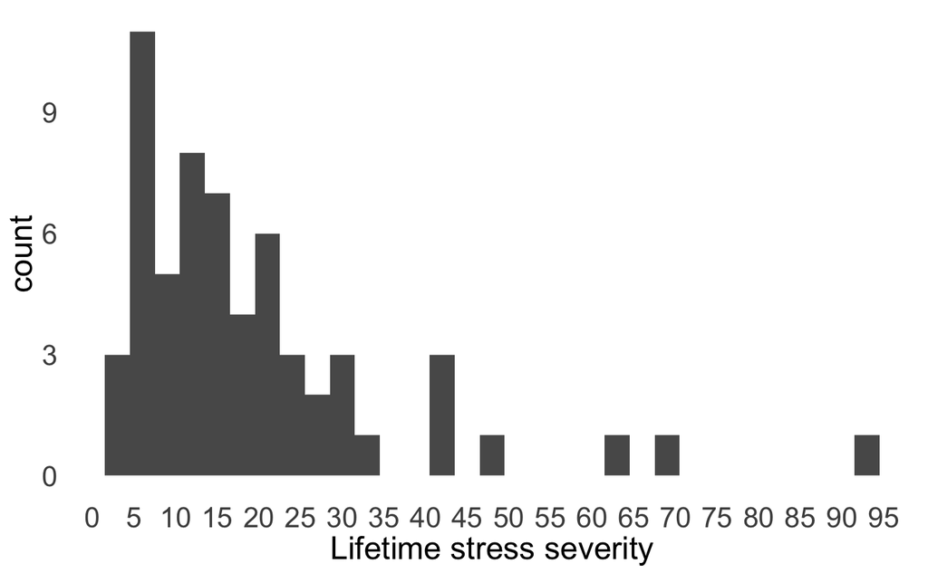

```r
lscr_preg %>%
  ggplot(aes(sum_sev)) +
  geom_histogram(binwidth = 3) +
  scale_x_continuous(breaks = seq.int(0, 100, 5)) +
  theme_minimal() +
  theme(
    panel.grid = element_blank(),
    plot.title = element_text(size = 20, hjust = .5),
    axis.title = element_text(size = 18),
    axis.text = element_text(size = 16),
    legend.title = element_text(size = 18),
    legend.text = element_text(size = 16)
  ) +
  labs(
    x = "Lifetime stress severity"
  )
```

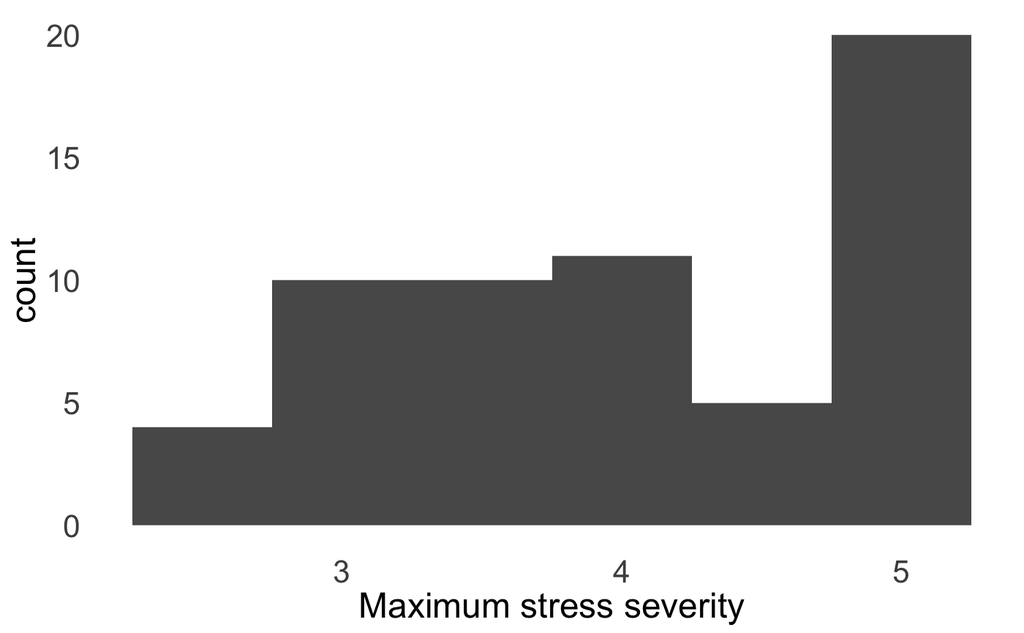

```r
lscr_preg %>%
  ggplot(aes(max_sev)) +
  geom_histogram(binwidth = .5) +
  scale_x_continuous(breaks = seq.int(0, 5, 1)) +
  theme_minimal() +
  theme(
    panel.grid = element_blank(),
    plot.title = element_text(size = 20, hjust = .5),
    axis.title = element_text(size = 18),
    axis.text = element_text(size = 16),
    legend.title = element_text(size = 18),
    legend.text = element_text(size = 16)
  ) +
  labs(
    x = "Maximum stress severity"
  )
```

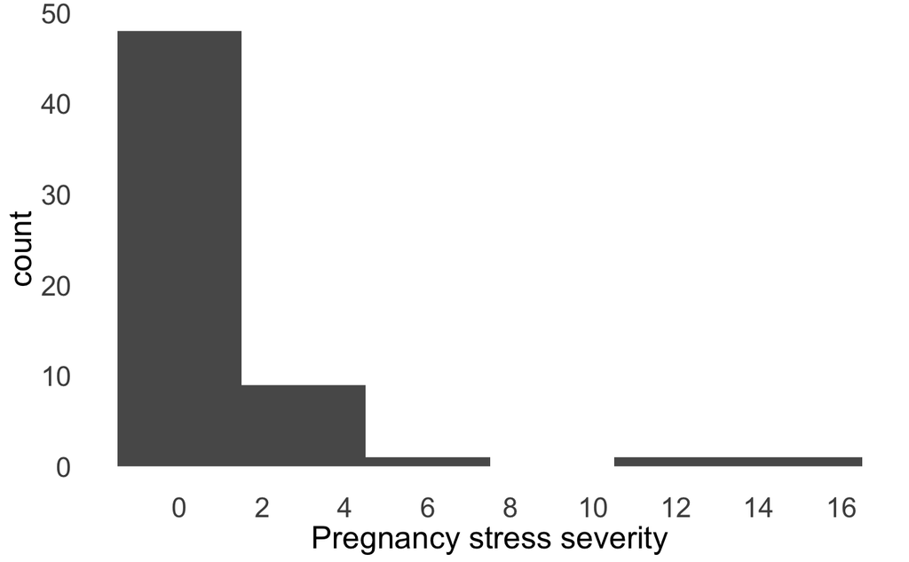

```r
lscr_preg %>%
  ggplot(aes(sum_sev_preg)) +
  geom_histogram(binwidth = 3) +
  theme_minimal() +
  scale_x_continuous(breaks = seq.int(0, 25, 2)) +
  theme(
    panel.grid = element_blank(),
    plot.title = element_text(size = 20, hjust = .5),
    axis.title = element_text(size = 18),
    axis.text = element_text(size = 16),
    legend.title = element_text(size = 18),
    legend.text = element_text(size = 16)
  ) +
  labs(
    x = "Pregnancy stress severity"
  )
```

```r
lscr_preg %>%
  count(maltreated) %>%
  mutate(
    per = n / sum(n)
  )
```

| maltreated | n | per |
| --- | --- | --- |
| maltreated | 27 | 0.45 |
| not maltreated | 33 | 0.55 |

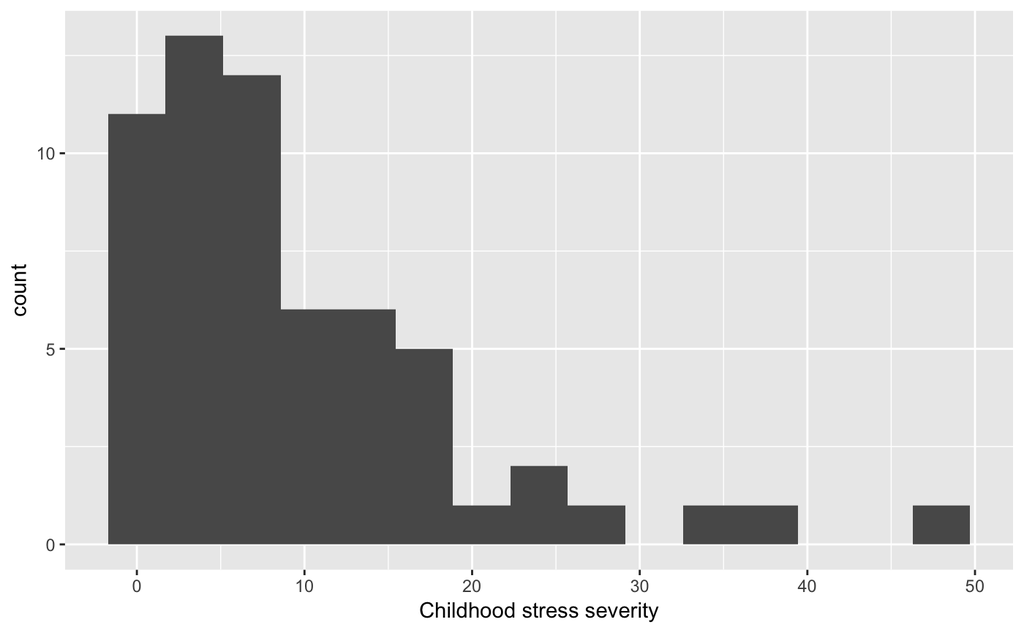

```r
lscr_preg %>%
  ggplot(aes(sum_sev_childhood)) +
  geom_histogram(bins = 15) +
  labs(x = "Childhood stress severity")
```

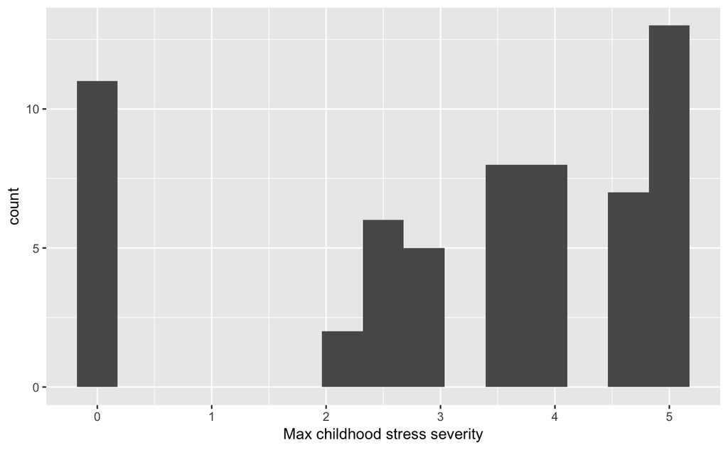

```r
lscr_preg %>%
  ggplot(aes(max_sev_childhood)) +
  geom_histogram(bins = 15) +
  labs(x = "Max childhood stress severity")
```

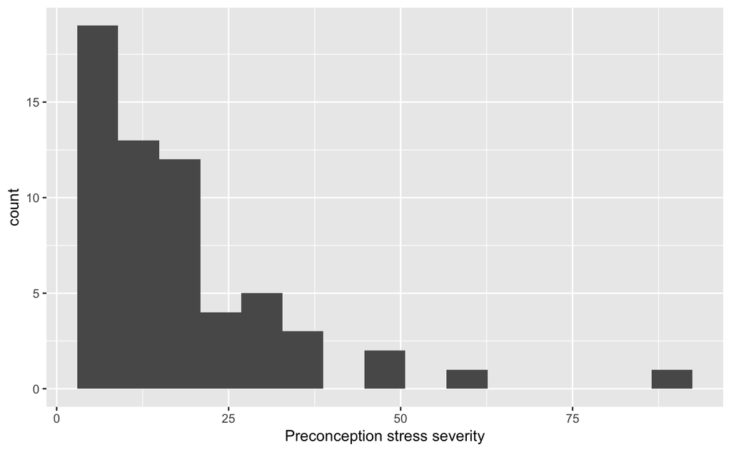

```r
lscr_preg %>%
  ggplot(aes(sum_sev_precon)) +
  geom_histogram(bins = 15) +
  labs(x = "Preconception stress severity")
```

## T1 frequency of stressors overall

```r
N_T1 <- n_distinct(lscr_preg$ID)
lscr_table <-
  lscr_preg %>%
  select(
    sev_vars
  ) %>%
  gather(type, rating, sev_con_disas:sev_con_other2) %>%
  group_by(type) %>%
  count(endorsed = !is.na(rating)) %>%
  ungroup() %>%
  filter(endorsed) %>%
  mutate(
    type = str_replace(type, "sev_con_", "")
  ) %>%
  select(-endorsed)
types_names <-
  lscr_table %>%
  select(type) %>%
  mutate(type = as.factor(type)) %>%
  pull(type) %>%
  levels()
lscr_table %>%
  mutate(
    type = factor(
      type,
      levels = types_names,
      labels = c(
        "abortion or miscarriage",
        "accident (self)",
        "adoption or foster care",
        "cartaker for close other",
        "sudden death of close other",
        "expected death of close other",
        "disaster",
        "divorce (self)",
        "domestic violence (adulthood)",
        "emotional abuse 1",
        "emotional abuse 2",
        "arrest/imprisonment of family",
        "domestic violence (childhood)",
        "serious physical illness (self)",
        "arrest/imprisonment (self)",
        "financial problems",
        "robbed/mugged/attacked (self)",
        "other (anything additional)",
        "other (happened to close other)",
        "parental separation/divorce",
        "physical abuse",
        "physical neglect",
        "rape (childhood)",
        "rape (adulthood)",
        "separated from child",
        "sexual harassment",
        "other sexual assault (childhood)",
        "other sexual assault (adulthood)",
        "witnessed accident",
        "witnessed robbery/mugging/attack"
      )
    ),
    type = fct_collapse(
      type,
      `emotional abuse/neglect` = c("emotional abuse 1", "emotional abuse 2")
    )
  ) %>%
  group_by(type) %>%
  summarise(
    n = sum(n),
    `proportion endorsed` = round(n / N_T1, 2)
  ) %>%
  arrange(desc(n)) %>%
  knitr::kable()
```

| type | n | proportion endorsed |
| --- | --- | --- |
| expected death of close other | 43 | 0.72 |
| abortion or miscarriage | 26 | 0.43 |
| parental separation/divorce | 25 | 0.42 |
| sudden death of close other | 22 | 0.37 |
| emotional abuse/neglect | 21 | 0.35 |
| witnessed accident | 21 | 0.35 |
| accident (self) | 20 | 0.33 |
| disaster | 18 | 0.30 |
| domestic violence (childhood) | 18 | 0.30 |
| sexual harassment | 17 | 0.28 |
| other (happened to close other) | 16 | 0.27 |
| robbed/mugged/attacked (self) | 15 | 0.25 |
| arrest/imprisonment of family | 14 | 0.23 |
| financial problems | 13 | 0.22 |
| cartaker for close other | 12 | 0.20 |
| other (anything additional) | 12 | 0.20 |
| rape (adulthood) | 12 | 0.20 |
| other sexual assault (childhood) | 10 | 0.17 |
| divorce (self) | 8 | 0.13 |
| domestic violence (adulthood) | 8 | 0.13 |
| physical abuse | 8 | 0.13 |
| witnessed robbery/mugging/attack | 6 | 0.10 |
| adoption or foster care | 4 | 0.07 |
| serious physical illness (self) | 4 | 0.07 |
| physical neglect | 4 | 0.07 |
| other sexual assault (adulthood) | 4 | 0.07 |
| arrest/imprisonment (self) | 3 | 0.05 |
| separated from child | 3 | 0.05 |
| rape (childhood) | 2 | 0.03 |

## T1 frequency of stressors in pregnancy

```r
lscr_table_pregnancy_stressors <-
  lscr_preg %>%
  select(
    preg_sev_vars
  ) %>%
  gather(type, rating, sev_preg_disas:sev_preg_other2) %>%
  group_by(type) %>%
  count(endorsed = !is.na(rating)) %>%
  ungroup() %>%
  filter(endorsed) %>%
  mutate(
    type = str_replace(type, "sev_preg_", "")
  ) %>%
  select(-endorsed)
types_preg_names <-
  lscr_table_pregnancy_stressors %>%
  select(type) %>%
  mutate(type = as.factor(type)) %>%
  pull(type) %>%
  levels()
lscr_table_pregnancy_stressors %>%
  mutate(
    type = factor(
      type,
      levels = types_preg_names,
      labels = c(
        "accident (self)",
        "caretaker for close other",
        "expected death of close other",
        "divorce (self)",
        "emotional abuse",
        "financial problems",
        "other (anything additional)",
        "separated from child",
        "sexual harassment",
        "witnessed accident"
      )
    )
  ) %>%
  group_by(type) %>%
  summarise(
    n = sum(n),
    `proportion endorsed` = round(n / N_T1, 2)
  ) %>%
  arrange(desc(n)) %>%
  knitr::kable()
```

| type | n | proportion endorsed |
| --- | --- | --- |
| expected death of close other | 5 | 0.08 |
| financial problems | 3 | 0.05 |
| caretaker for close other | 2 | 0.03 |
| divorce (self) | 2 | 0.03 |
| emotional abuse | 2 | 0.03 |
| sexual harassment | 2 | 0.03 |
| witnessed accident | 2 | 0.03 |
| accident (self) | 1 | 0.02 |
| other (anything additional) | 1 | 0.02 |
| separated from child | 1 | 0.02 |

```r
lscr_preg %>%
  count(num_stress_preg)
```

| num_stress_preg | n |
| --- | --- |
| 0 | 45 |
| 1 | 12 |
| 2 | 1 |
| 3 | 1 |
| 4 | 1 |

## T1 frequency of stressors in childhood

```r
lscr_table_childhood_stressors <-
  lscr_preg %>%
  select(
    child_sev_vars
  ) %>%
  gather(type, rating, sev_child_disas:sev_child_other2) %>%
  group_by(type) %>%
  count(endorsed = !is.na(rating)) %>%
  ungroup() %>%
  filter(endorsed) %>%
  mutate(
    type = str_replace(type, "sev_child_", "")
  ) %>%
  select(-endorsed)
types_child_names <-
  lscr_table_childhood_stressors %>%
  select(type) %>%
  mutate(type = as.factor(type)) %>%
  pull(type) %>%
  levels()
lscr_table_childhood_stressors %>%
  mutate(
    type = factor(
      type,
      levels = types_child_names,
      labels = c(
        "abortion or miscarriage",
        "accident (self)",
        "adoption or foster care",
        "caretaker for close other",
        "sudden death of close other",
        "expected death of close other",
        "disaster",
        "domestic violence (adulthood)",
        "emotional abuse 1",
        "emotional abuse 2",
        "arrest/imprisonment of family",
        "domestic violence (childhood)",
        "serious physical illness (self)",
        "arrest/imprisonment (self)",
        "financial problems",
        "robbed/mugged/attacked (self)",
        "other (anything additional)",
        "other (happened to close other)",
        "parental separation/divorce",
        "physical abuse",
        "physical neglect",
        "rape (childhood)",
        "rape (adulthood)",
        "sexual harassment",
        "other sexual assault (childhood)",
        "other sexual assault (adulthood)",
        "witnessed accident",
        "witnessed robbery/mugging/attack"
      )
    ),
    type = fct_collapse(
      type,
      `emotional abuse/neglect` = c("emotional abuse 1", "emotional abuse 2"),
      `rape` = c("rape (childhood)", "rape (adulthood)"),
      `other sexual assault` = c("other sexual assault (childhood)", "other sexual assault (adulthood)")
    )
  ) %>%
  group_by(type) %>%
  summarise(
    n = sum(n),
    `proportion endorsed` = round(n / N_T1, 2)
  ) %>%
  arrange(desc(n)) %>%
  knitr::kable()
```

| type | n | proportion endorsed |
| --- | --- | --- |
| parental separation/divorce | 19 | 0.32 |
| domestic violence (childhood) | 17 | 0.28 |
| disaster | 13 | 0.22 |
| expected death of close other | 12 | 0.20 |
| other sexual assault | 12 | 0.20 |
| emotional abuse/neglect | 11 | 0.18 |
| arrest/imprisonment of family | 8 | 0.13 |
| other (happened to close other) | 8 | 0.13 |
| physical abuse | 8 | 0.13 |
| other (anything additional) | 7 | 0.12 |
| accident (self) | 6 | 0.10 |
| caretaker for close other | 6 | 0.10 |
| sudden death of close other | 5 | 0.08 |
| robbed/mugged/attacked (self) | 5 | 0.08 |
| sexual harassment | 5 | 0.08 |
| adoption or foster care | 4 | 0.07 |
| physical neglect | 4 | 0.07 |
| rape | 4 | 0.07 |
| witnessed accident | 4 | 0.07 |
| witnessed robbery/mugging/attack | 4 | 0.07 |
| domestic violence (adulthood) | 3 | 0.05 |
| abortion or miscarriage | 2 | 0.03 |
| serious physical illness (self) | 2 | 0.03 |
| arrest/imprisonment (self) | 2 | 0.03 |
| financial problems | 2 | 0.03 |

# LSC-R T3 (6 months)

## Read in T3 data

```r
lscr_6mo <-
  readxl::read_xlsx(stress_ratings_cs_file1) %>%
  rename(ID = record_id) %>%
  select(
    -contains("date")
  ) %>%
  bind_rows(
    readxl::read_xlsx(stress_ratings_cs_file2) %>%
      rename(ID = record_id) %>%
      select(-contains("date"))
  ) %>%
  mutate_at(
    vars(contains("preg"), "ID"),
    as.integer
  ) %>%
  mutate_at(
    vars(contains("Sev")),
    as.double
  ) %>%
  left_join(
    dates %>%
      select(
        ID,
        baby_due_date,
        mom_age_conception,
        mom_age_babydob
      ),
    by = "ID"
  )
```

```
-
/
```

```
* lscr_acc_date -> lscr_acc_date...30
* lscr_acc_date -> lscr_acc_date...33
```

```
Expecting numeric in DP8 / R8C120: got a date
```

```
/
```

```
NAs introduced by coercion
```

```r
glimpse(lscr_6mo)
```

```
Observations: 96
Variables: 313
$ ID                       <dbl> 21, 34, 46, 47, 89, 1, 18, 27, 35, 48, 58, 79, 123, 24, 31, 40, 65, 88, 102, 127, …
$ redcap_event_name        <chr> "interaction_visit_arm_1", "interaction_visit_arm_1", "interaction_visit_arm_1", "…
$ redcap_survey_identifier <lgl> NA, NA, NA, NA, NA, NA, NA, NA, NA, NA, NA, NA, NA, NA, NA, NA, NA, NA, NA, NA, NA…
$ lscr_file                <lgl> NA, NA, NA, NA, NA, NA, NA, NA, NA, NA, NA, NA, NA, NA, NA, NA, NA, NA, NA, NA, NA…
$ lscr_interviewer         <chr> "Sarah (STC)", "Sarah (STC)", "MR", "VV", NA, "Carly (CL)", "Sarah (STC)", "Sarah …
$ lscr_disas               <dbl> 1, 1, 1, 1, 1, 1, 1, 1, 1, 1, 1, 1, 1, 1, 1, 1, 1, 1, 1, 1, 1, 1, 1, 1, 1, 1, 1, 1…
$ lscr_disas_age           <dbl> 7, 10, 4, 9, 23, 13, 10, 20, 9, 8, 11, 31, 4, 9, 23, 10, 26, 6, 8, 22, 17, 13, 18,…
$ lscr_disas_preg          <int> 0, 0, 0, 0, 0, 0, 0, 0, 0, 0, 0, 0, 0, 0, 0, 0, 0, 0, 0, 0, 0, 0, 0, 0, 0, 0, 0, 0…
$ lscr_disas_sev           <dbl> 4, 4, 4, 4, 4, 3, 3, 3, 3, 3, 3, 3, 3, 2, 2, 2, 2, 2, 2, 2, 2, 1, 1, 1, 1, 1, 1, 1…
$ lscr_disas_intp          <dbl> 0, 0, 0, 0, 1, NA, 0, 0, 1, 0, 0, 1, 0, 0, 0, 0, 0, 0, 0, 0, 1, 0, 0, 0, 0, 0, 0, …
$ lscr_notes               <chr> "1985 Mexico City earthquake. Major earthquake. No deaths that she knew. Her part …
$ sev_kh_disas             <dbl> 2.5, 1.0, 2.5, 2.5, NA, 3.0, 3.0, 1.0, 2.5, 2.5, 2.5, 2.0, NA, 2.5, 1.0, 2.5, 1.0,…
$ sev_lk_disas             <dbl> 2.5, 1.0, 2.5, 2.5, 3.5, 4.0, 2.5, 1.0, 2.5, 2.5, 2.5, 2.5, 2.5, 2.5, 1.0, 2.5, 1.…
```

[output cut: 300 more lines]

## Calculate T3 reliability

```r
lscr_lk <-
  lscr_6mo %>%
  select(
    ID,
    contains("sev_lk")
  ) %>%
  gather(variable, rater1, sev_lk_disas:sev_lk_other3) %>%
  mutate(
    variable = str_replace(variable, "lk_", "")
  ) %>%
  na.omit()
lscr_kh <-
  lscr_6mo %>%
  select(
    ID,
    contains("sev_kh")
  ) %>%
  gather(variable, rater2, sev_kh_disas:sev_kh_other3) %>%
  mutate(
    variable = str_replace(variable, "kh_", "")
  ) %>%
  na.omit()
lscr_ls <-
  lscr_6mo %>%
  select(
    ID,
    contains("sev_ls")
  ) %>%
  gather(variable, rater2, sev_ls_disas:sev_ls_other3) %>%
  mutate(
    variable = str_replace(variable, "ls_", "")
  ) %>%
  na.omit()
lscr_icc_lk_ls <-
  lscr_lk %>%
  left_join(lscr_ls, by = c("ID", "variable")) %>%
  select(-ID, -variable) %>%
  na.omit()
ICC(lscr_icc_lk_ls)
```

```
boundary (singular) fit: see ?isSingular
```

```
Call: ICC(x = lscr_icc_lk_ls)

Intraclass correlation coefficients
```

|  | type | ICC | F | df1 | df2 | p | lower bound | upper bound |
| --- | --- | --- | --- | --- | --- | --- | --- | --- |
| Single_raters_absolute | ICC1 | 0.5134216 | 4.165502 | 42 | 86 | 1.086253e-08 | 0.3359700 | 0.6750451 |
| Single_random_raters | ICC2 | 0.5134216 | 4.165502 | 42 | 84 | 1.348964e-08 | 0.3359141 | 0.6750676 |
| Single_fixed_raters | ICC3 | 0.5134216 | 4.165502 | 42 | 84 | 1.348964e-08 | 0.3350004 | 0.6754343 |
| Average_raters_absolute | ICC1k | 0.7599329 | 4.165502 | 42 | 86 | 1.086253e-08 | 0.6028386 | 0.8617267 |
| Average_random_raters | ICC2k | 0.7599329 | 4.165502 | 42 | 84 | 1.348964e-08 | 0.6027786 | 0.8617389 |
| Average_fixed_raters | ICC3k | 0.7599329 | 4.165502 | 42 | 84 | 1.348964e-08 | 0.6017968 | 0.8619380 |

```
 Number of subjects = 43     Number of Judges =  3
```

```r
lscr_icc_lk_kh <-
  lscr_lk %>%
  left_join(lscr_kh, by = c("ID", "variable")) %>%
  select(-ID, -variable) %>%
  na.omit()
ICC(lscr_icc_lk_kh)
```

```
Call: ICC(x = lscr_icc_lk_kh)

Intraclass correlation coefficients
```

|  | type | ICC | F | df1 | df2 | p | lower bound | upper bound |
| --- | --- | --- | --- | --- | --- | --- | --- | --- |
| Single_raters_absolute | ICC1 | 0.9674910 | 60.52147 | 300 | 301 | 5.356072e-182 | 0.9593935 | 0.9739964 |
| Single_random_raters | ICC2 | 0.9674946 | 60.93642 | 300 | 300 | 6.805441e-182 | 0.9593658 | 0.9740157 |
| Single_fixed_raters | ICC3 | 0.9677088 | 60.93642 | 300 | 300 | 6.805441e-182 | 0.9596561 | 0.9741754 |
| Average_raters_absolute | ICC1k | 0.9834769 | 60.52147 | 300 | 301 | 5.356072e-182 | 0.9792760 | 0.9868269 |
| Average_random_raters | ICC2k | 0.9834788 | 60.93642 | 300 | 300 | 6.805441e-182 | 0.9792616 | 0.9868368 |
| Average_fixed_raters | ICC3k | 0.9835895 | 60.93642 | 300 | 300 | 6.805441e-182 | 0.9794127 | 0.9869188 |

```
 Number of subjects = 301     Number of Judges =  2
```

## Calculate T3 total scores

```r
#save variable names in order to map later
preg_exp_vars_6mo <-
  lscr_6mo %>%
  select(contains("preg")) %>%
  names()
exp_vars_6mo <-
  lscr_6mo %>%
  select(contains("preg")) %>%
  names() %>%
  str_replace("_preg", "")
sev_vars_6mo <-
  lscr_6mo %>%
  select(contains("sev_con")) %>%
  names()
#add total scores: n lifetime, objective severity lifetime, n pregnancy
lscr_6mo <-
  lscr_6mo %>%
  mutate_at(
    vars(exp_vars_6mo),
    as.integer
  ) %>%
  mutate_at(
    vars(preg_exp_vars_6mo),
    as.integer
  ) %>%
  mutate(
    num_stress_total =
      pmap_int(
        select(., exp_vars_6mo),
        function(...) sum(c(...), na.rm = TRUE)
      ),
    num_stress_preg =
      pmap_int(
        select(., preg_exp_vars_6mo),
        function(...) sum(c(...), na.rm = TRUE)
      ),
    sum_sev =
      pmap_dbl(
        select(., sev_vars_6mo),
        function(...) sum(c(...), na.rm = TRUE)
      ),
    max_sev =
      pmap_dbl(
        select(., sev_vars_6mo),
        function(...) max(c(...), na.rm = TRUE)
      ),
    pregnancy_stress =
      if_else(
        num_stress_preg > 0,
        "yes", "no"
      )
  ) %>%
  mutate(
    max_sev = if_else(
      max_sev == -Inf,
      0, max_sev
    ),
    #objective severity ratings during pregnancy
    sev_preg_disas = calc_preg_sev(lscr_disas_preg, sev_con_disas),
    sev_preg_witacc = calc_preg_sev(lscr_witacc_preg, sev_con_witacc),
    sev_preg_acc = calc_preg_sev(lscr_acc_preg, sev_con_acc),
    sev_preg_famjail = calc_preg_sev(lscr_famjail_preg, sev_con_famjail),
    sev_preg_jail = calc_preg_sev(lscr_jail_preg, sev_con_jail),
    sev_preg_adopt = calc_preg_sev(lscr_adopt_preg, sev_con_adopt),
    sev_preg_pardivorce = calc_preg_sev(lscr_pardivorce_preg, sev_con_pardivorce),
    sev_preg_divorce = calc_preg_sev(lscr_divorce_preg, sev_con_divorce),
    sev_preg_money = calc_preg_sev(lscr_money_preg, sev_con_money),
    sev_preg_ill = calc_preg_sev(lscr_ill_preg, sev_con_ill),
    sev_preg_emoab = calc_preg_sev(lscr_emoab_preg, sev_con_emoab),
    sev_preg_physneg = calc_preg_sev(lscr_physneg_preg, sev_con_physneg),
    sev_preg_abort = calc_preg_sev(lscr_abort_preg, sev_con_abort),
    sev_preg_sepchild = calc_preg_sev(lscr_sepchild_preg, sev_con_sepchild),
    sev_preg_care = calc_preg_sev(lscr_care_preg, sev_con_care),
    sev_preg_death1 = calc_preg_sev(lscr_death1_preg, sev_con_death1),
    sev_preg_death2 = calc_preg_sev(lscr_death2_preg, sev_con_death2),
    sev_preg_famviol = calc_preg_sev(lscr_famviol_preg, sev_con_famviol),
    sev_preg_witmug = calc_preg_sev(lscr_witmug_preg, sev_con_witmug),
    sev_preg_mug = calc_preg_sev(lscr_mug_preg, sev_con_mug),
    sev_preg_physab = calc_preg_sev(lscr_physab_preg, sev_con_physab),
    sev_preg_domviol = calc_preg_sev(lscr_domviol_preg, sev_con_domviol),
    sev_preg_sexharas = calc_preg_sev(lscr_sexharas_preg, sev_con_sexharas),
    sev_preg_sextouch1 = calc_preg_sev(lscr_sextouch1_preg, sev_con_sextouch1),
    sev_preg_sextouch2 = calc_preg_sev(lscr_sextouch2_preg, sev_con_sextouch2),
    sev_preg_rape1 = calc_preg_sev(lscr_rape1_preg, sev_con_rape1),
    sev_preg_rape2 = calc_preg_sev(lscr_rape2_preg, sev_con_rape2),
    sev_preg_other1 = calc_preg_sev(lscr_other1_preg, sev_con_other1),
    sev_preg_other2 = calc_preg_sev(lscr_other2_preg, sev_con_other2),
    sev_preg_other2 = calc_preg_sev(lscr_other2_preg, sev_con_other3)
  )
#save variable names to map over
preg_sev_vars_6mo <-
  lscr_6mo %>%
  select(starts_with("sev_preg")) %>%
  names()
#calculate pregnancy objective severity
lscr_6mo <-
  lscr_6mo %>%
  mutate(
    sum_sev_preg =
      pmap_dbl(
        select(., preg_sev_vars_6mo),
        function(...) sum(c(...), na.rm = TRUE)
      ),
    max_sev_preg =
      pmap_dbl(
        select(., preg_sev_vars_6mo),
        function(...) max(c(...), na.rm = TRUE)
      ),
    max_sev_preg = if_else(
      max_sev_preg == -Inf,
      0, max_sev_preg
    )
  )
```

# T3 stress by developmental stage

get frequencies of each type in childhood vs. adulthood and separate sum sev get frequencies of childhood maltreatment and sum sev

```r
age_vars_6mo <-
  lscr_6mo %>%
  select(contains("_age")) %>%
  names()
lscr_6mo <-
  lscr_6mo %>%
  mutate_at(
    vars(age_vars_6mo),
    .funs = funs("devstage" = calc_dev_stage(.))
  ) %>%
  mutate(
    #objective ratings of childhood stress
    sev_child_disas = calc_sev_childhood(lscr_disas_age_devstage, sev_con_disas),
    sev_child_witacc = calc_sev_childhood(lscr_witacc_age_devstage, sev_con_witacc),
    sev_child_acc = calc_sev_childhood(lscr_acc_age_devstage, sev_con_acc),
    sev_child_famjail = calc_sev_childhood(lscr_famjail_age_devstage, sev_con_famjail),
    sev_child_jail = calc_sev_childhood(lscr_jail_age_devstage, sev_con_jail),
    sev_child_adopt = calc_sev_childhood(lscr_adopt_age_devstage, sev_con_adopt),
    sev_child_pardivorce = calc_sev_childhood(lscr_pardivorce_age_devstage, sev_con_pardivorce),
    sev_child_divorce = calc_sev_childhood(lscr_divorce_age_devstage, sev_con_divorce),
    sev_child_money = calc_sev_childhood(lscr_money_age_devstage, sev_con_money),
    sev_child_ill = calc_sev_childhood(lscr_ill_age_devstage, sev_con_ill),
    sev_child_emoab = calc_sev_childhood(lscr_emoab_age_devstage, sev_con_emoab),
    sev_child_physneg = calc_sev_childhood(lscr_physneg_age_devstage, sev_con_physneg),
    sev_child_abort = calc_sev_childhood(lscr_abort_age_devstage, sev_con_abort),
    sev_child_sepchild = calc_sev_childhood(lscr_sepchild_age_devstage, sev_con_sepchild),
    sev_child_care = calc_sev_childhood(lscr_care_age_devstage, sev_con_care),
    sev_child_death1 = calc_sev_childhood(lscr_death1_age_devstage, sev_con_death1),
    sev_child_death2 = calc_sev_childhood(lscr_death2_age_devstage, sev_con_death2),
    sev_child_famviol = calc_sev_childhood(lscr_famviol_age_devstage, sev_con_famviol),
    sev_child_witmug = calc_sev_childhood(lscr_witmug_age_devstage, sev_con_witmug),
    sev_child_mug = calc_sev_childhood(lscr_mug_age_devstage, sev_con_mug),
    sev_child_physab = calc_sev_childhood(lscr_physab_age_devstage, sev_con_physab),
    sev_child_domviol = calc_sev_childhood(lscr_domviol_age_devstage, sev_con_domviol),
    sev_child_sexharas = calc_sev_childhood(lscr_sexharas_age_devstage, sev_con_sexharas),
    sev_child_sextouch1 = calc_sev_childhood(lscr_sextouch1_age_devstage, sev_con_sextouch1),
    sev_child_sextouch2 = calc_sev_childhood(lscr_sextouch2_age_devstage, sev_con_sextouch2),
    sev_child_rape1 = calc_sev_childhood(lscr_rape1_age_devstage, sev_con_rape1),
    sev_child_rape2 = calc_sev_childhood(lscr_rape2_age_devstage, sev_con_rape2),
    sev_child_other1 = calc_sev_childhood(lscr_other1_age_devstage, sev_con_other1),
    sev_child_disas = calc_sev_childhood(lscr_disas_age_devstage, sev_con_disas),
    sev_child_witacc = calc_sev_childhood(lscr_witacc_age_devstage, sev_con_witacc),
    sev_child_acc = calc_sev_childhood(lscr_acc_age_devstage, sev_con_acc),
    sev_child_famjail = calc_sev_childhood(lscr_famjail_age_devstage, sev_con_famjail),
    sev_child_jail = calc_sev_childhood(lscr_jail_age_devstage, sev_con_jail),
    sev_child_adopt = calc_sev_childhood(lscr_adopt_age_devstage, sev_con_adopt),
    sev_child_pardivorce = calc_sev_childhood(lscr_pardivorce_age_devstage, sev_con_pardivorce),
    sev_child_divorce = calc_sev_childhood(lscr_divorce_age_devstage, sev_con_divorce),
    sev_child_money = calc_sev_childhood(lscr_money_age_devstage, sev_con_money),
    sev_child_ill = calc_sev_childhood(lscr_ill_age_devstage, sev_con_ill),
    sev_child_emoab = calc_sev_childhood(lscr_emoab_age_devstage, sev_con_emoab),
    sev_child_physneg = calc_sev_childhood(lscr_physneg_age_devstage, sev_con_physneg),
    sev_child_abort = calc_sev_childhood(lscr_abort_age_devstage, sev_con_abort),
    sev_child_sepchild = calc_sev_childhood(lscr_sepchild_age_devstage, sev_con_sepchild),
    sev_child_care = calc_sev_childhood(lscr_care_age_devstage, sev_con_care),
    sev_child_death1 = calc_sev_childhood(lscr_death1_age_devstage, sev_con_death1),
    sev_child_death2 = calc_sev_childhood(lscr_death2_age_devstage, sev_con_death2),
    sev_child_famviol = calc_sev_childhood(lscr_famviol_age_devstage, sev_con_famviol),
    sev_child_witmug = calc_sev_childhood(lscr_witmug_age_devstage, sev_con_witmug),
    sev_child_mug = calc_sev_childhood(lscr_mug_age_devstage, sev_con_mug),
    sev_child_physab = calc_sev_childhood(lscr_physab_age_devstage, sev_con_physab),
    sev_child_domviol = calc_sev_childhood(lscr_domviol_age_devstage, sev_con_domviol),
    sev_child_sexharas = calc_sev_childhood(lscr_sexharas_age_devstage, sev_con_sexharas),
    sev_child_sextouch1 = calc_sev_childhood(lscr_sextouch1_age_devstage, sev_con_sextouch1),
    sev_child_sextouch2 = calc_sev_childhood(lscr_sextouch2_age_devstage, sev_con_sextouch2),
    sev_child_rape1 = calc_sev_childhood(lscr_rape1_age_devstage, sev_con_rape1),
    sev_child_rape2 = calc_sev_childhood(lscr_rape2_age_devstage, sev_con_rape2),
    sev_child_other1 = calc_sev_childhood(lscr_other1_age_devstage, sev_con_other1),
    sev_child_other2 = calc_sev_childhood(lscr_other2_age_devstage, sev_con_other2),
    sev_child_other3 = calc_sev_childhood(lscr_other3_age_devstage, sev_con_other3)
  )
child_sev_vars_6mo <-
  lscr_6mo %>%
  select(contains("sev_child")) %>%
  names()
lscr_6mo <-
  lscr_6mo %>%
  mutate(
    sum_sev_childhood =
      pmap_dbl(
        select(., child_sev_vars_6mo),
        function(...) sum(c(...), na.rm = TRUE)
      ),
    max_sev_childhood =
      pmap_dbl(
        select(., child_sev_vars_6mo),
        function(...) max(c(...), na.rm = TRUE)
      ),
    max_sev_childhood = if_else(
      max_sev_childhood == -Inf,
      0, max_sev_childhood
    ),
    sum_sev_maltreatment =
      pmap_dbl(
        select(
          .,
          sev_child_emoab,
          sev_child_physab,
          sev_child_physneg,
          sev_child_adopt,
          sev_child_rape1,
          sev_child_rape2,
          sev_child_sextouch1,
          sev_child_sextouch2,
          sev_child_sexharas
        ),
        function(...) sum(c(...), na.rm = TRUE)
      ),
    maltreated = if_else(
      sum_sev_maltreatment > 0,
      "maltreated", "not maltreated"
    )
  )
```

## T3 stress by life stage in correspondance to pregnancy: preconception, postnatal

NOTE! life stages are based on when stressors STARTED. Some stressors started prior to conception but are coded as happening in pregnancy because they extended into pregnancy. There is no postnatal stress measured at T1 because T1 is during pregnancy.

### identify life stage for each report

```r
#identify life stages for each stressor
lscr_6mo <-
  lscr_6mo %>%
  mutate(
    lscr_disas_lifestage = calc_preg_life_stage(
      lscr_disas_age, lscr_disas_preg, mom_age_conception, mom_age_babydob
    ),
    lscr_witacc_lifestage = calc_preg_life_stage(
      lscr_witacc_age, lscr_witacc_preg, mom_age_conception, mom_age_babydob
    ),
    lscr_acc_lifestage = calc_preg_life_stage(
      lscr_acc_age, lscr_acc_preg, mom_age_conception, mom_age_babydob
    ),
    lscr_famjail_lifestage = calc_preg_life_stage(
      lscr_famjail_age, lscr_famjail_preg, mom_age_conception, mom_age_babydob
    ),
    lscr_jail_lifestage = calc_preg_life_stage(
      lscr_jail_age, lscr_jail_preg, mom_age_conception, mom_age_babydob
    ),
    lscr_adopt_lifestage = calc_preg_life_stage(
      lscr_adopt_age, lscr_adopt_preg, mom_age_conception, mom_age_babydob
    ),
    lscr_pardivorce_lifestage = calc_preg_life_stage(
      lscr_pardivorce_age, lscr_pardivorce_preg, mom_age_conception, mom_age_babydob
    ),
    lscr_divorce_lifestage = calc_preg_life_stage(
      lscr_divorce_age, lscr_divorce_preg, mom_age_conception, mom_age_babydob
    ),
    lscr_money_lifestage = calc_preg_life_stage(
      lscr_money_age, lscr_money_preg, mom_age_conception, mom_age_babydob
    ),
    lscr_ill_lifestage = calc_preg_life_stage(
      lscr_ill_age, lscr_ill_preg, mom_age_conception, mom_age_babydob
    ),
    lscr_emoab_lifestage = calc_preg_life_stage(
      lscr_emoab_age, lscr_emoab_preg, mom_age_conception, mom_age_babydob
    ),
    lscr_physneg_lifestage = calc_preg_life_stage(
      lscr_physneg_age, lscr_physneg_preg, mom_age_conception, mom_age_babydob
    ),
    lscr_abort_lifestage = calc_preg_life_stage(
      lscr_abort_age, lscr_abort_preg, mom_age_conception, mom_age_babydob
    ),
    lscr_abort_lifestage = calc_preg_life_stage(
      lscr_abort_age, lscr_abort_preg, mom_age_conception, mom_age_babydob
    ),
    lscr_sepchild_lifestage = calc_preg_life_stage(
      lscr_sepchild_age, lscr_sepchild_preg, mom_age_conception, mom_age_babydob
    ),
    lscr_care_lifestage = calc_preg_life_stage(
      lscr_care_age, lscr_care_preg, mom_age_conception, mom_age_babydob
    ),
    lscr_death1_lifestage = calc_preg_life_stage(
      lscr_death1_age, lscr_death1_preg, mom_age_conception, mom_age_babydob
    ),
    lscr_death2_lifestage = calc_preg_life_stage(
      lscr_death2_age, lscr_death2_preg, mom_age_conception, mom_age_babydob
    ),
    lscr_famviol_lifestage = calc_preg_life_stage(
      lscr_famviol_age, lscr_famviol_preg, mom_age_conception, mom_age_babydob
    ),
    lscr_witmug_lifestage = calc_preg_life_stage(
      lscr_witmug_age, lscr_witmug_preg, mom_age_conception, mom_age_babydob
    ),
    lscr_mug_lifestage = calc_preg_life_stage(
      lscr_mug_age, lscr_mug_preg, mom_age_conception, mom_age_babydob
    ),
    lscr_physab_lifestage = calc_preg_life_stage(
      lscr_physab_age, lscr_physab_preg, mom_age_conception, mom_age_babydob
    ),
    lscr_domviol_lifestage = calc_preg_life_stage(
      lscr_domviol_age, lscr_domviol_preg, mom_age_conception, mom_age_babydob
    ),
    lscr_sexharas_lifestage = calc_preg_life_stage(
      lscr_sexharas_age, lscr_sexharas_preg, mom_age_conception, mom_age_babydob
    ),
    lscr_sextouch1_lifestage = calc_preg_life_stage(
      lscr_sextouch1_age, lscr_sextouch1_preg, mom_age_conception, mom_age_babydob
    ),
    lscr_sextouch2_lifestage = calc_preg_life_stage(
      lscr_sextouch2_age, lscr_sextouch2_preg, mom_age_conception, mom_age_babydob
    ),
    lscr_rape1_lifestage = calc_preg_life_stage(
      lscr_rape1_age, lscr_rape1_preg, mom_age_conception, mom_age_babydob
    ),
    lscr_rape2_lifestage = calc_preg_life_stage(
      lscr_rape2_age, lscr_rape2_preg, mom_age_conception, mom_age_babydob
    ),
    lscr_other1_lifestage = calc_preg_life_stage(
      lscr_other1_age, lscr_other1_preg, mom_age_conception, mom_age_babydob
    ),
    lscr_other2_lifestage = calc_preg_life_stage(
      lscr_other2_age, lscr_other2_preg, mom_age_conception, mom_age_babydob
    ),
    lscr_other3_lifestage = calc_preg_life_stage(
      lscr_other3_age, lscr_other3_preg, mom_age_conception, mom_age_babydob
    )
  )
```

## calculate severity of preconception stressors

```r
lscr_6mo <-
  lscr_6mo %>%
  mutate(
    #objective preconception severity ratings
    sev_precon_disas = calc_sev_preconception(lscr_disas_lifestage, sev_con_disas),
    sev_precon_witacc = calc_sev_preconception(lscr_witacc_lifestage, sev_con_witacc),
    sev_precon_acc = calc_sev_preconception(lscr_acc_lifestage, sev_con_acc),
    sev_precon_famjail = calc_sev_preconception(lscr_famjail_lifestage, sev_con_famjail),
    sev_precon_jail = calc_sev_preconception(lscr_jail_lifestage, sev_con_jail),
    sev_precon_adopt = calc_sev_preconception(lscr_adopt_lifestage, sev_con_adopt),
    sev_precon_pardivorce = calc_sev_preconception(lscr_pardivorce_lifestage, sev_con_pardivorce),
    sev_precon_divorce = calc_sev_preconception(lscr_divorce_lifestage, sev_con_divorce),
    sev_precon_money = calc_sev_preconception(lscr_money_lifestage, sev_con_money),
    sev_precon_ill = calc_sev_preconception(lscr_ill_lifestage, sev_con_ill),
    sev_precon_emoab = calc_sev_preconception(lscr_emoab_lifestage, sev_con_emoab),
    sev_precon_abort = calc_sev_preconception(lscr_abort_lifestage, sev_con_abort),
    sev_precon_sep = calc_sev_preconception(lscr_sepchild_lifestage, sev_con_sepchild),
    sev_precon_care = calc_sev_preconception(lscr_care_lifestage, sev_con_care),
    sev_precon_death1 = calc_sev_preconception(lscr_death1_lifestage, sev_con_death1),
    sev_precon_death2 = calc_sev_preconception(lscr_death2_lifestage, sev_con_death2),
    sev_precon_famviol = calc_sev_preconception(lscr_famviol_lifestage, sev_con_famviol),
    sev_precon_witmug = calc_sev_preconception(lscr_witmug_lifestage, sev_con_witmug),
    sev_precon_mug = calc_sev_preconception(lscr_mug_lifestage, sev_con_mug),
    sev_precon_physab = calc_sev_preconception(lscr_physab_lifestage, sev_con_physab),
    sev_precon_domviol = calc_sev_preconception(lscr_domviol_lifestage, sev_con_domviol),
    sev_precon_sexharas = calc_sev_preconception(lscr_sexharas_lifestage, sev_con_sexharas),
    sev_precon_sextouch1 = calc_sev_preconception(lscr_sextouch1_lifestage, sev_con_sextouch1),
    sev_precon_sextouch2 = calc_sev_preconception(lscr_sextouch2_lifestage, sev_con_sextouch2),
    sev_precon_rape1 = calc_sev_preconception(lscr_rape1_lifestage, sev_con_rape1),
    sev_precon_rape2 = calc_sev_preconception(lscr_rape2_lifestage, sev_con_rape2),
    sev_precon_other1 = calc_sev_preconception(lscr_other1_lifestage, sev_con_other1),
    sev_precon_other2 = calc_sev_preconception(lscr_other2_lifestage, sev_con_other2),
    sev_precon_other3 = calc_sev_preconception(lscr_other2_lifestage, sev_con_other2)
  )
precon_6mo_sev_vars <-
  lscr_6mo %>%
  select(contains("sev_precon")) %>%
  names()
precon_6mo_sev_vars <-
  lscr_6mo %>%
  select(contains("sev_precon")) %>%
  names()
lscr_6mo <-
  lscr_6mo %>%
  mutate(
    sum_sev_precon =
      pmap_dbl(
        select(., precon_6mo_sev_vars),
        function(...) sum(c(...), na.rm = TRUE)
      ),
    max_sev_precon =
      pmap_dbl(
        select(., precon_6mo_sev_vars),
        function(...) max(c(...), na.rm = TRUE)
      ),
    max_sev_precon = if_else(
      max_sev_precon == -Inf,
      0, max_sev_precon
    )
  )
```

## calculate severity of postnatal stressors

```r
calc_sev_postnatal <- function(life_stage, sev) {
   case_when(
    life_stage == "postnatal" ~ sev,
    TRUE ~ NA_real_
  )
}
lscr_6mo <-
  lscr_6mo %>%
  mutate(
    sev_postnat_disas = calc_sev_postnatal(lscr_disas_lifestage, sev_con_disas),
    sev_postnat_witacc = calc_sev_postnatal(lscr_witacc_lifestage, sev_con_witacc),
    sev_postnat_acc = calc_sev_postnatal(lscr_acc_lifestage, sev_con_acc),
    sev_postnat_famjail = calc_sev_postnatal(lscr_famjail_lifestage, sev_con_famjail),
    sev_postnat_jail = calc_sev_postnatal(lscr_jail_lifestage, sev_con_jail),
    sev_postnat_adopt = calc_sev_postnatal(lscr_adopt_lifestage, sev_con_adopt),
    sev_postnat_pardivorce = calc_sev_postnatal(lscr_pardivorce_lifestage, sev_con_pardivorce),
    sev_postnat_divorce = calc_sev_postnatal(lscr_divorce_lifestage, sev_con_divorce),
    sev_postnat_money = calc_sev_postnatal(lscr_money_lifestage, sev_con_money),
    sev_postnat_ill = calc_sev_postnatal(lscr_ill_lifestage, sev_con_ill),
    sev_postnat_emoab = calc_sev_postnatal(lscr_emoab_lifestage, sev_con_emoab),
    sev_postnat_abort = calc_sev_postnatal(lscr_abort_lifestage, sev_con_abort),
    sev_postnat_sep = calc_sev_postnatal(lscr_sepchild_lifestage, sev_con_sepchild),
    sev_postnat_care = calc_sev_postnatal(lscr_care_lifestage, sev_con_care),
    sev_postnat_death1 = calc_sev_postnatal(lscr_death1_lifestage, sev_con_death1),
    sev_postnat_death2 = calc_sev_postnatal(lscr_death2_lifestage, sev_con_death2),
    sev_postnat_famviol = calc_sev_postnatal(lscr_famviol_lifestage, sev_con_famviol),
    sev_postnat_witmug = calc_sev_postnatal(lscr_witmug_lifestage, sev_con_witmug),
    sev_postnat_mug = calc_sev_postnatal(lscr_mug_lifestage, sev_con_mug),
    sev_postnat_physab = calc_sev_postnatal(lscr_physab_lifestage, sev_con_physab),
    sev_postnat_domviol = calc_sev_postnatal(lscr_domviol_lifestage, sev_con_domviol),
    sev_postnat_sexharas = calc_sev_postnatal(lscr_sexharas_lifestage, sev_con_sexharas),
    sev_postnat_sextouch1 = calc_sev_postnatal(lscr_sextouch1_lifestage, sev_con_sextouch1),
    sev_postnat_sextouch2 = calc_sev_postnatal(lscr_sextouch2_lifestage, sev_con_sextouch2),
    sev_postnat_rape1 = calc_sev_postnatal(lscr_rape1_lifestage, sev_con_rape1),
    sev_postnat_rape2 = calc_sev_postnatal(lscr_rape2_lifestage, sev_con_rape2),
    sev_postnat_other1 = calc_sev_postnatal(lscr_other1_lifestage, sev_con_other1),
    sev_postnat_other2 = calc_sev_postnatal(lscr_other2_lifestage, sev_con_other2),
    sev_postnat_other3 = calc_sev_postnatal(lscr_other2_lifestage, sev_con_other2)
  )
postnatal_6mo_sev_vars <-
  lscr_6mo %>%
  select(contains("sev_postnat")) %>%
  names()
lscr_6mo <-
  lscr_6mo %>%
  mutate(
    sum_sev_postnatal =
      pmap_dbl(
        select(., postnatal_6mo_sev_vars),
        function(...) sum(c(...), na.rm = TRUE)
      ),
    max_sev_postnatal =
      pmap_dbl(
        select(., postnatal_6mo_sev_vars),
        function(...) max(c(...), na.rm = TRUE)
      ),
    max_sev_postnatal = if_else(
      max_sev_postnatal == -Inf,
      0, max_sev_postnatal
    )
  )
```

## Examine T3 distributions

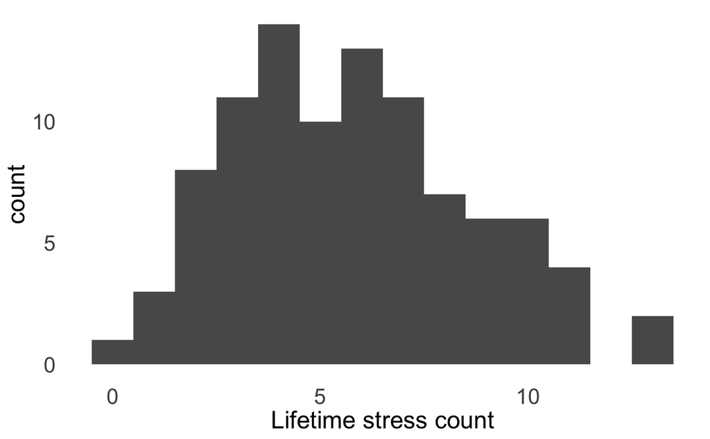

```r
lscr_6mo %>%
  ggplot(aes(num_stress_total)) +
  geom_histogram(binwidth = 1) +
  scale_x_continuous(breaks = seq.int(0, 30, 5)) +
  theme_minimal() +
  theme(
    panel.grid = element_blank(),
    plot.title = element_text(size = 20, hjust = .5),
    axis.title = element_text(size = 18),
    axis.text = element_text(size = 16),
    legend.title = element_text(size = 18),
    legend.text = element_text(size = 16)
  ) +
  labs(
    x = "Lifetime stress count"
  )
```

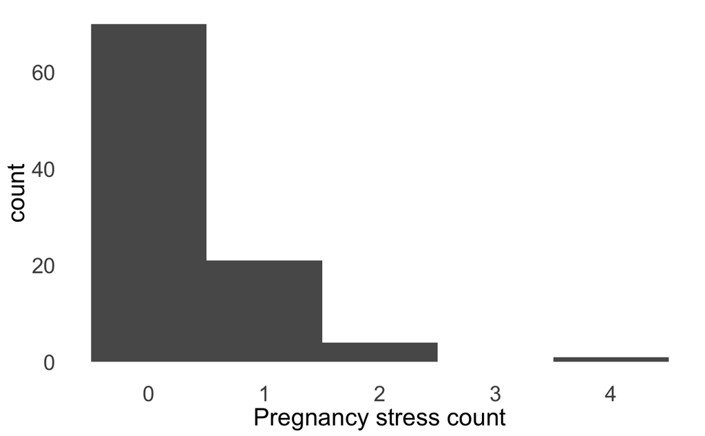

```r
lscr_6mo %>%
  ggplot(aes(num_stress_preg)) +
  geom_histogram(binwidth = 1) +
  scale_x_continuous(breaks = seq.int(0, 30, 1)) +
  theme_minimal() +
  theme(
    panel.grid = element_blank(),
    plot.title = element_text(size = 20, hjust = .5),
    axis.title = element_text(size = 18),
    axis.text = element_text(size = 16),
    legend.title = element_text(size = 18),
    legend.text = element_text(size = 16)
  ) +
  labs(
    x = "Pregnancy stress count"
  )
```

```r
lscr_6mo %>%
  count(num_stress_preg)
```

| num_stress_preg | n |
| --- | --- |
| 0 | 70 |
| 1 | 21 |
| 2 | 4 |
| 4 | 1 |

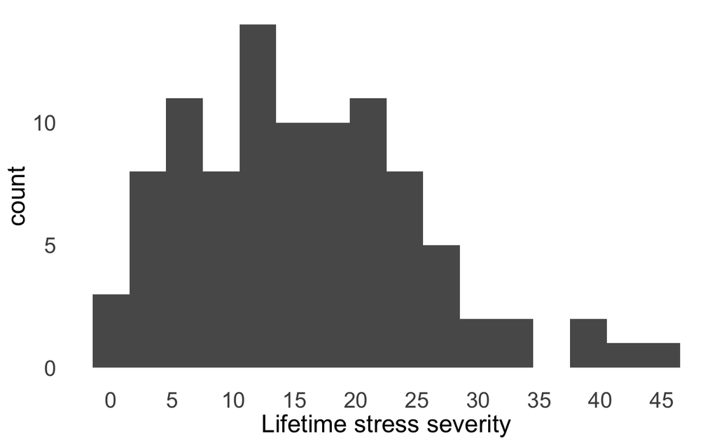

```r
lscr_6mo %>%
  ggplot(aes(sum_sev)) +
  geom_histogram(binwidth = 3) +
  scale_x_continuous(breaks = seq.int(0, 100, 5)) +
  theme_minimal() +
  theme(
    panel.grid = element_blank(),
    plot.title = element_text(size = 20, hjust = .5),
    axis.title = element_text(size = 18),
    axis.text = element_text(size = 16),
    legend.title = element_text(size = 18),
    legend.text = element_text(size = 16)
  ) +
  labs(
    x = "Lifetime stress severity"
  )
```

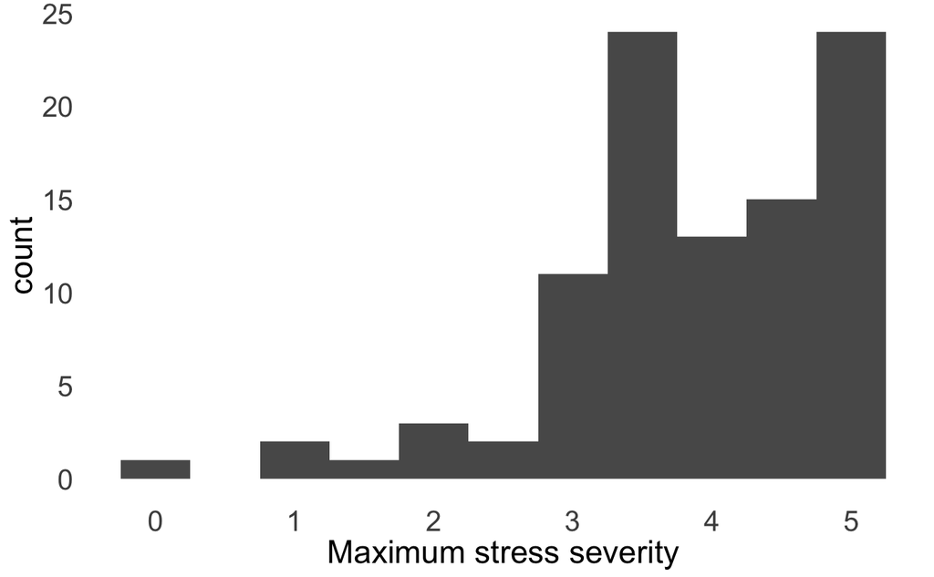

```r
lscr_6mo %>%
  ggplot(aes(max_sev)) +
  geom_histogram(binwidth = .5) +
  scale_x_continuous(breaks = seq.int(0, 5, 1)) +
  theme_minimal() +
  theme(
    panel.grid = element_blank(),
    plot.title = element_text(size = 20, hjust = .5),
    axis.title = element_text(size = 18),
    axis.text = element_text(size = 16),
    legend.title = element_text(size = 18),
    legend.text = element_text(size = 16)
  ) +
  labs(
    x = "Maximum stress severity"
  )
```

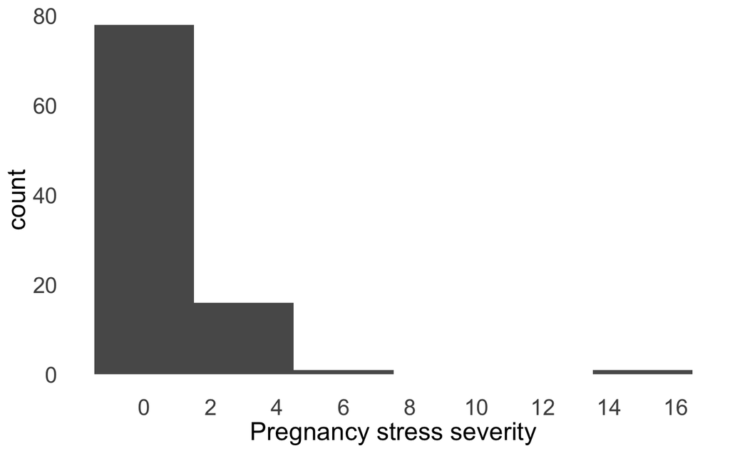

```r
lscr_6mo %>%
  ggplot(aes(sum_sev_preg)) +
  geom_histogram(binwidth = 3) +
  theme_minimal() +
  scale_x_continuous(breaks = seq.int(0, 25, 2)) +
  theme(
    panel.grid = element_blank(),
    plot.title = element_text(size = 20, hjust = .5),
    axis.title = element_text(size = 18),
    axis.text = element_text(size = 16),
    legend.title = element_text(size = 18),
    legend.text = element_text(size = 16)
  ) +
  labs(
    x = "Pregnancy stress severity"
  )
```

```r
lscr_6mo %>%
  count(maltreated) %>%
  mutate(
    per = n / sum(n)
  )
```

| maltreated | n | per |
| --- | --- | --- |
| maltreated | 46 | 0.4791667 |
| not maltreated | 50 | 0.5208333 |

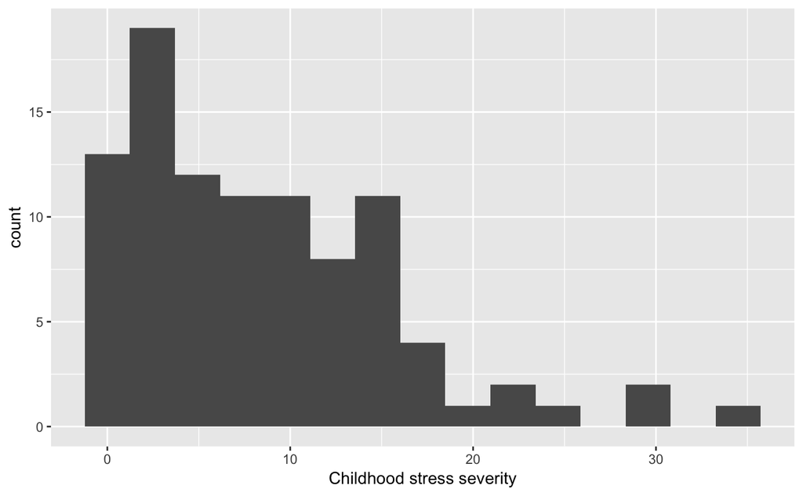

```r
lscr_6mo %>%
  ggplot(aes(sum_sev_childhood)) +
  geom_histogram(bins = 15) +
  labs(x = "Childhood stress severity")
```

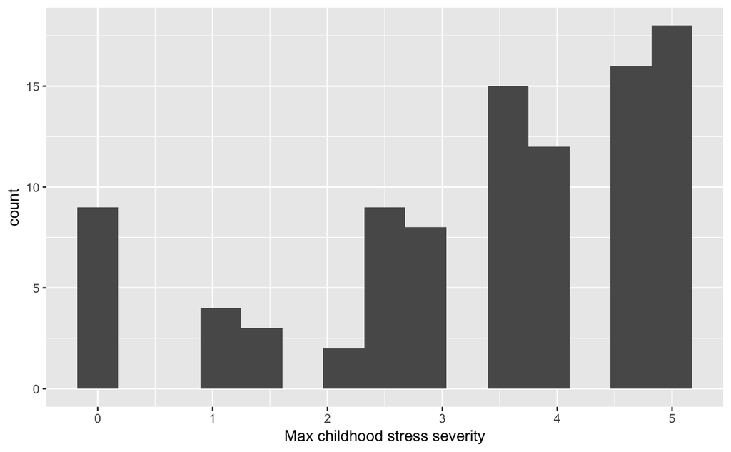

```r
lscr_6mo %>%
  ggplot(aes(max_sev_childhood)) +
  geom_histogram(bins = 15) +
  labs(x = "Max childhood stress severity")
```

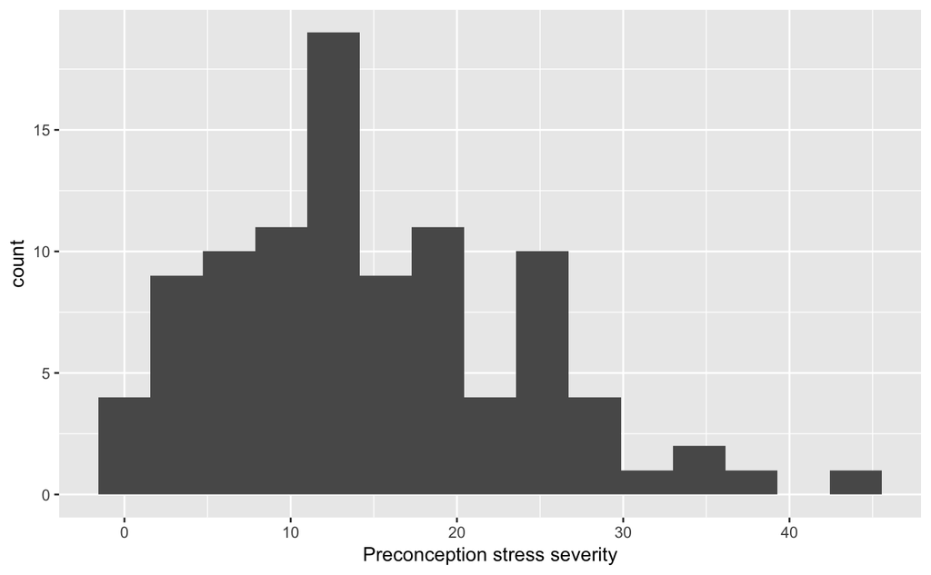

```r
lscr_6mo %>%
  ggplot(aes(sum_sev_precon)) +
  geom_histogram(bins = 15) +
  labs(x = "Preconception stress severity")
```

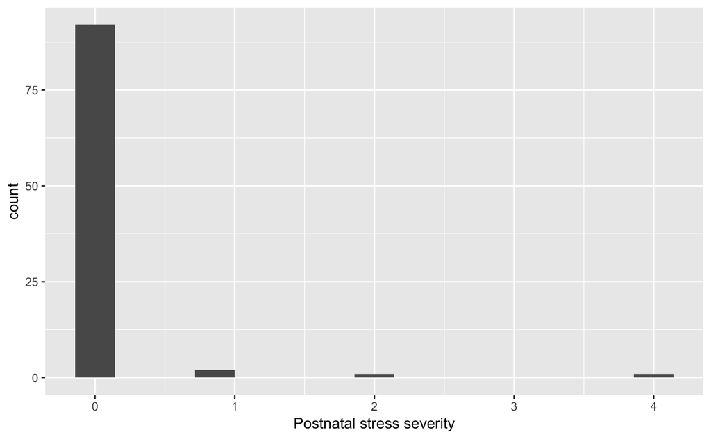

```r
lscr_6mo %>%
  ggplot(aes(sum_sev_postnatal)) +
  geom_histogram(bins = 15) +
  labs(x = "Postnatal stress severity")
```

# T3 frequency of stressors overall

```r
N_6mo <- n_distinct(lscr_6mo$ID)
lscr_table_6mo <-
  lscr_6mo %>%
  select(
    sev_vars_6mo
  ) %>%
  gather(type, rating, sev_con_disas:sev_con_other3) %>%
  group_by(type) %>%
  count(endorsed = !is.na(rating)) %>%
  ungroup() %>%
  filter(endorsed) %>%
  mutate(
    type = str_replace(type, "sev_con_", "")
  ) %>%
  select(-endorsed)
types_names_6mo <-
  lscr_table_6mo %>%
  select(type) %>%
  mutate(type = as.factor(type)) %>%
  pull(type) %>%
  levels()
lscr_table_6mo %>%
  mutate(
    type = factor(
      type,
      levels = types_names_6mo,
      labels = c(
        "abortion or miscarriage",
        "accident (self)",
        "adoption or foster care",
        "caretaker for close other",
        "sudden death of close other",
        "expected death of close other",
        "disaster",
        "divorce (self)",
        "domestic violence (adulthood)",
        "emotional abuse",
        "arrest/imprisonment of family",
        "domestic violence (childhood)",
        "serious physical illness (self)",
        "arrest/imprisonment (self)",
        "financial problems",
        "robbed/mugged/attacked (self)",
        "other 1 (anything additional)",
        "other (happened to close other)",
        "other 2 (anything additional)",
        "parental separation/divorce",
        "physical abuse",
        "physical neglect",
        "rape (childhood)",
        "rape (adulthood)",
        "sexual harassment",
        "other sexual assault (childhood)",
        "other sexual assault (adulthood)",
        "witnessed accident",
        "witnessed robbery/mugging/attack"
      )
    ),
    type = fct_collapse(
      type,
      `other (anything additional)` = c(
        "other 1 (anything additional)",
        "other 2 (anything additional)"
      )
    )
  ) %>%
  group_by(type) %>%
  summarise(
    n = sum(n),
    `proportion endorsed` = round(n / N_6mo, 2)
  ) %>%
  arrange(desc(n)) %>%
  knitr::kable()
```

| type | n | proportion endorsed |
| --- | --- | --- |
| expected death of close other | 65 | 0.68 |
| sudden death of close other | 41 | 0.43 |
| disaster | 36 | 0.38 |
| abortion or miscarriage | 32 | 0.33 |
| other (happened to close other) | 32 | 0.33 |
| sexual harassment | 32 | 0.33 |
| witnessed accident | 32 | 0.33 |
| accident (self) | 29 | 0.30 |
| domestic violence (childhood) | 29 | 0.30 |
| parental separation/divorce | 27 | 0.28 |
| emotional abuse | 26 | 0.27 |
| other (anything additional) | 25 | 0.26 |
| arrest/imprisonment of family | 18 | 0.19 |
| robbed/mugged/attacked (self) | 17 | 0.18 |
| other sexual assault (childhood) | 15 | 0.16 |
| physical abuse | 13 | 0.14 |
| witnessed robbery/mugging/attack | 13 | 0.14 |
| caretaker for close other | 12 | 0.12 |
| rape (adulthood) | 10 | 0.10 |
| financial problems | 9 | 0.09 |
| physical neglect | 7 | 0.07 |
| rape (childhood) | 6 | 0.06 |
| domestic violence (adulthood) | 5 | 0.05 |
| arrest/imprisonment (self) | 4 | 0.04 |
| other sexual assault (adulthood) | 4 | 0.04 |
| adoption or foster care | 3 | 0.03 |
| divorce (self) | 3 | 0.03 |
| serious physical illness (self) | 3 | 0.03 |

# T3 frequency of stressors in pregnancy

```r
lscr_table_pregnancy_stressors_6mo <-
  lscr_6mo %>%
  select(
    preg_sev_vars_6mo
  ) %>%
  gather(type, rating, sev_preg_disas:sev_preg_other2) %>%
  group_by(type) %>%
  count(endorsed = !is.na(rating)) %>%
  ungroup() %>%
  filter(endorsed) %>%
  mutate(
    type = str_replace(type, "sev_preg_", "")
  ) %>%
  select(-endorsed)
types_preg_names_6mo <-
  lscr_table_pregnancy_stressors_6mo %>%
  select(type) %>%
  mutate(type = as.factor(type)) %>%
  pull(type) %>%
  levels()
lscr_table_pregnancy_stressors_6mo %>%
  mutate(
    type = factor(
      type,
      levels = types_preg_names_6mo,
      labels = c(
        "caretaker for close other",
        "sudden death of close other",
        "expected death of close other",
        "emotional abuse",
        "serious physical illness (self)",
        "financial problems",
        "robbed/mugged/attacked (self)",
        "other (anything additional)",
        "parental separation/divorce",
        "physical abuse",
        "sexual harassment",
        "other sexual assault",
        "witnessed accident"
      )
    )
  ) %>%
  group_by(type) %>%
  summarise(
    n = sum(n),
    `proportion endorsed` = round(n / N_6mo, 2)
  ) %>%
  arrange(desc(n)) %>%
  knitr::kable()
```

| type | n | proportion endorsed |
| --- | --- | --- |
| expected death of close other | 5 | 0.05 |
| sudden death of close other | 4 | 0.04 |
| emotional abuse | 3 | 0.03 |
| caretaker for close other | 2 | 0.02 |
| financial problems | 2 | 0.02 |
| robbed/mugged/attacked (self) | 2 | 0.02 |
| other (anything additional) | 2 | 0.02 |
| sexual harassment | 2 | 0.02 |
| serious physical illness (self) | 1 | 0.01 |
| parental separation/divorce | 1 | 0.01 |
| physical abuse | 1 | 0.01 |
| other sexual assault | 1 | 0.01 |
| witnessed accident | 1 | 0.01 |

```r
lscr_preg %>%
  count(num_stress_preg)
```

| num_stress_preg | n |
| --- | --- |
| 0 | 45 |
| 1 | 12 |
| 2 | 1 |
| 3 | 1 |
| 4 | 1 |

# T3 Frequency of stressors in childhood

```r
lscr_table_childhood_stressors_6mo <-
  lscr_6mo %>%
  select(
    child_sev_vars_6mo
  ) %>%
  gather(type, rating, sev_child_disas:sev_child_other2) %>%
  group_by(type) %>%
  count(endorsed = !is.na(rating)) %>%
  ungroup() %>%
  filter(endorsed) %>%
  mutate(
    type = str_replace(type, "sev_child_", "")
  ) %>%
  select(-endorsed)
types_child_names_6mo <-
  lscr_table_childhood_stressors_6mo %>%
  select(type) %>%
  mutate(type = as.factor(type)) %>%
  pull(type) %>%
  levels()
lscr_table_childhood_stressors_6mo %>%
  mutate(
    type = factor(
      type,
      levels = types_child_names_6mo,
      labels = c(
        "abortion or miscarriage",
        "accident (self)",
        "adoption or foster care",
        "caretaker for close other",
        "sudden death of close other",
        "expected death of close other",
        "disaster",
        "domestic violence (adulthood)",
        "emotional abuse",
        "arrest/imprisonment of family",
        "domestic violence (childhood)",
        "arrest/imprisonment (self)",
        "financial problems",
        "robbed/mugged/attacked (self)",
        "other (anything additional)",
        "other (happened to close other)",
        "parental separation/divorce",
        "physical abuse",
        "physical neglect",
        "rape (childhood)",
        "rape (adulthood)",
        "sexual harassment",
        "other sexual assault (childhood)",
        "other sexual assault (adulthood)",
        "witnessed accident",
        "witnessed robbery/mugging/attack"
      )
    ),
    type = fct_collapse(
      type,
      `rape` = c("rape (childhood)", "rape (adulthood)"),
      `other sexual assault` = c("other sexual assault (childhood)", "other sexual assault (adulthood)"),
      `domestic violence` = c("domestic violence (adulthood)", "domestic violence (childhood)")
    )
  ) %>%
  group_by(type) %>%
  summarise(
    n = sum(n),
    `proportion endorsed` = round(n / N_6mo, 2)
  ) %>%
  arrange(desc(n)) %>%
  knitr::kable()
```

| type | n | proportion endorsed |
| --- | --- | --- |
| domestic violence | 30 | 0.31 |
| disaster | 28 | 0.29 |
| emotional abuse | 24 | 0.25 |
| expected death of close other | 22 | 0.23 |
| parental separation/divorce | 21 | 0.22 |
| other sexual assault | 17 | 0.18 |
| sudden death of close other | 13 | 0.14 |
| physical abuse | 13 | 0.14 |
| accident (self) | 12 | 0.12 |
| arrest/imprisonment of family | 11 | 0.11 |
| other (happened to close other) | 10 | 0.10 |
| witnessed accident | 10 | 0.10 |
| robbed/mugged/attacked (self) | 8 | 0.08 |
| rape | 8 | 0.08 |
| sexual harassment | 8 | 0.08 |
| physical neglect | 7 | 0.07 |
| other (anything additional) | 6 | 0.06 |
| witnessed robbery/mugging/attack | 6 | 0.06 |
| abortion or miscarriage | 3 | 0.03 |
| adoption or foster care | 3 | 0.03 |
| caretaker for close other | 3 | 0.03 |
| financial problems | 2 | 0.02 |
| arrest/imprisonment (self) | 1 | 0.01 |

# Merge LSC-R across time points

```r
lscr_T1lg_6mocs <-
  lscr_T1lg_6mocs %>%
  mutate(
    sum_sev_child_win = winsorize(x = sum_sev_childhood, product = 3),
    sum_sev_precon_win = winsorize(x = sum_sev_precon, product = 3),
    num_stress_total_win = winsorize(x = num_stress_total, product = 3),
    sum_sev_win = winsorize(x = sum_sev, product = 3)
  )
```

```
Error: must be a double vector, not an integer vector
Call `rlang::last_error()` to see a backtrace
```

## Examine merged data distributions

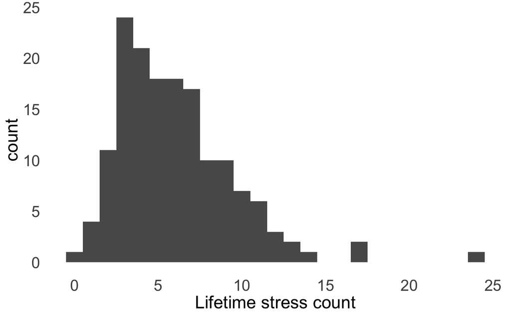

```r
lscr_T1lg_6mocs %>%
  ggplot(aes(num_stress_total)) +
  geom_histogram(binwidth = 1) +
  scale_x_continuous(breaks = seq.int(0, 30, 5)) +
  theme_minimal() +
  theme(
    panel.grid = element_blank(),
    plot.title = element_text(size = 20, hjust = .5),
    axis.title = element_text(size = 18),
    axis.text = element_text(size = 16),
    legend.title = element_text(size = 18),
    legend.text = element_text(size = 16)
  ) +
  labs(
    x = "Lifetime stress count"
  )
```

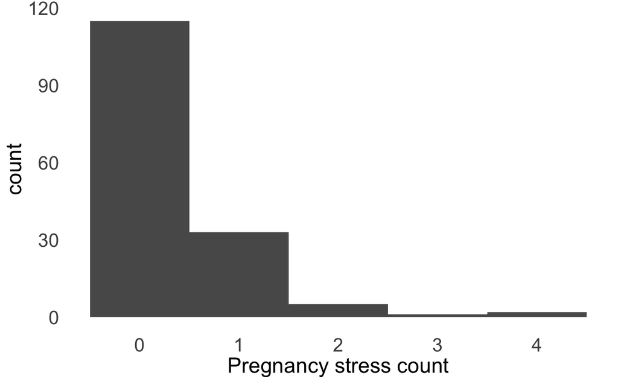

```r
lscr_T1lg_6mocs %>%
  ggplot(aes(num_stress_preg)) +
  geom_histogram(binwidth = 1) +
  scale_x_continuous(breaks = seq.int(0, 30, 1)) +
  theme_minimal() +
  theme(
    panel.grid = element_blank(),
    plot.title = element_text(size = 20, hjust = .5),
    axis.title = element_text(size = 18),
    axis.text = element_text(size = 16),
    legend.title = element_text(size = 18),
    legend.text = element_text(size = 16)
  ) +
  labs(
    x = "Pregnancy stress count"
  )
```

```r
lscr_T1lg_6mocs %>%
  count(num_stress_preg)
```

| num_stress_preg | n |
| --- | --- |
| 0 | 115 |
| 1 | 33 |
| 2 | 5 |
| 3 | 1 |
| 4 | 2 |

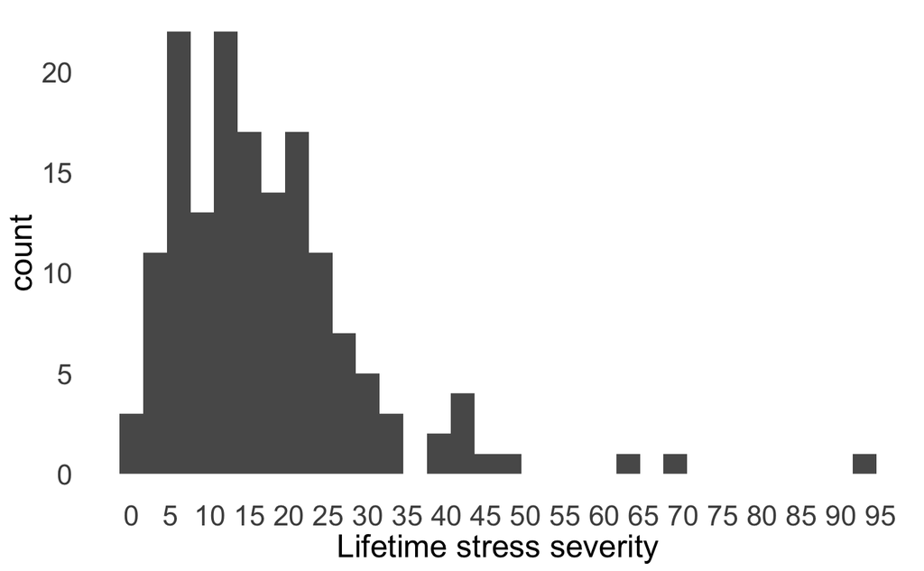

```r
lscr_T1lg_6mocs %>%
  ggplot(aes(sum_sev)) +
  geom_histogram(binwidth = 3) +
  scale_x_continuous(breaks = seq.int(0, 100, 5)) +
  theme_minimal() +
  theme(
    panel.grid = element_blank(),
    plot.title = element_text(size = 20, hjust = .5),
    axis.title = element_text(size = 18),
    axis.text = element_text(size = 16),
    legend.title = element_text(size = 18),
    legend.text = element_text(size = 16)
  ) +
  labs(
    x = "Lifetime stress severity"
  )
```

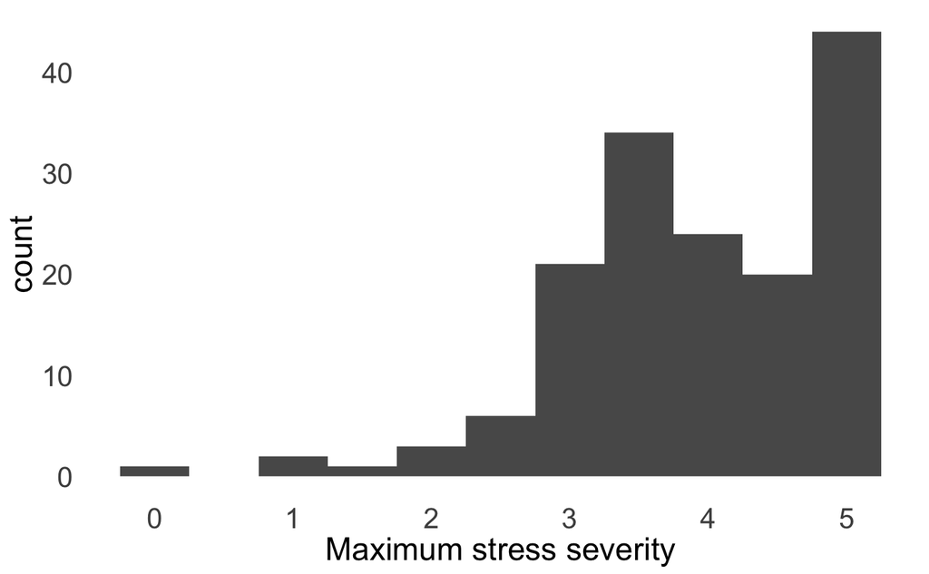

```r
lscr_T1lg_6mocs %>%
  ggplot(aes(max_sev)) +
  geom_histogram(binwidth = .5) +
  scale_x_continuous(breaks = seq.int(0, 5, 1)) +
  theme_minimal() +
  theme(
    panel.grid = element_blank(),
    plot.title = element_text(size = 20, hjust = .5),
    axis.title = element_text(size = 18),
    axis.text = element_text(size = 16),
    legend.title = element_text(size = 18),
    legend.text = element_text(size = 16)
  ) +
  labs(
    x = "Maximum stress severity"
  )
```

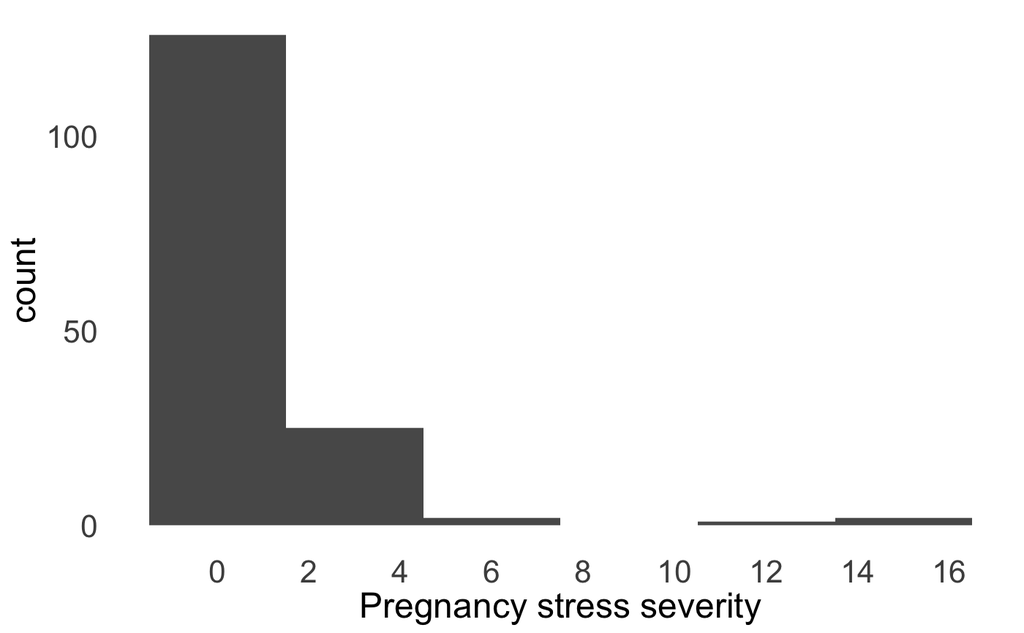

```r
lscr_T1lg_6mocs %>%
  ggplot(aes(sum_sev_preg)) +
  geom_histogram(binwidth = 3) +
  theme_minimal() +
  scale_x_continuous(breaks = seq.int(0, 25, 2)) +
  theme(
    panel.grid = element_blank(),
    plot.title = element_text(size = 20, hjust = .5),
    axis.title = element_text(size = 18),
    axis.text = element_text(size = 16),
    legend.title = element_text(size = 18),
    legend.text = element_text(size = 16)
  ) +
  labs(
    x = "Pregnancy stress severity"
  )
```

```r
lscr_T1lg_6mocs %>%
  count(maltreated) %>%
  mutate(
    per = n / sum(n)
  )
```

| maltreated | n | per |
| --- | --- | --- |
| maltreated | 73 | 0.4679487 |
| not maltreated | 83 | 0.5320513 |

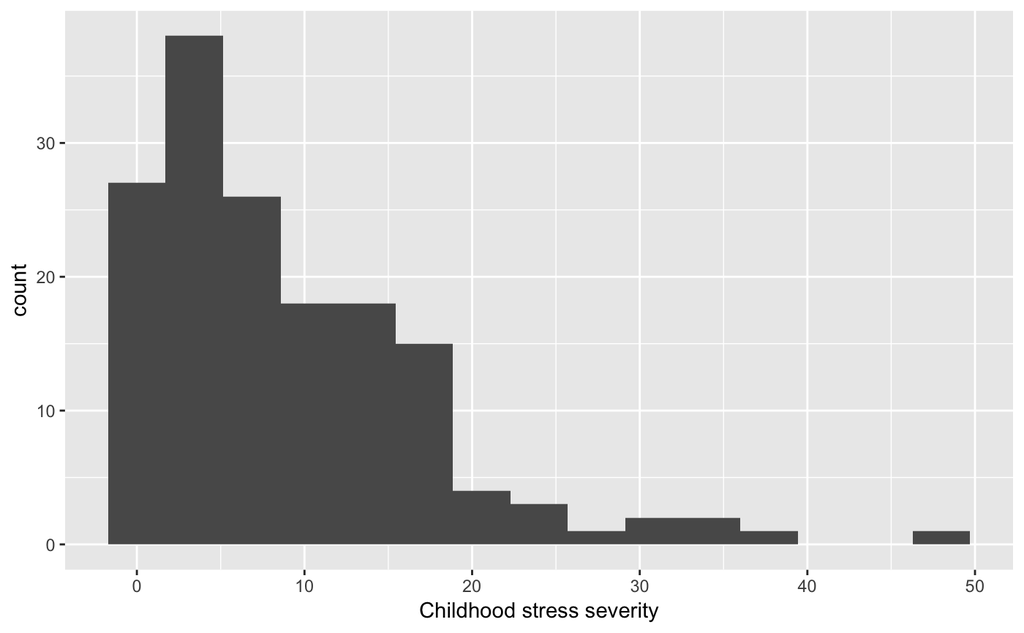

```r
lscr_T1lg_6mocs %>%
  ggplot(aes(sum_sev_childhood)) +
  geom_histogram(bins = 15) +
  labs(x = "Childhood stress severity")
```

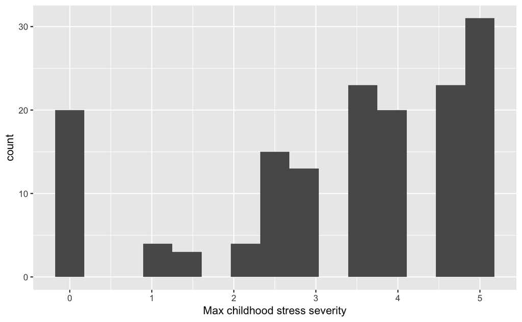

```r
lscr_T1lg_6mocs %>%
  ggplot(aes(max_sev_childhood)) +
  geom_histogram(bins = 15) +
  labs(x = "Max childhood stress severity")
```

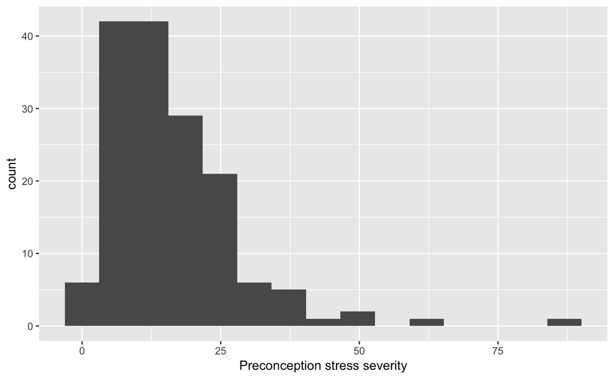

```r
lscr_T1lg_6mocs %>%
  ggplot(aes(sum_sev_precon)) +
  geom_histogram(bins = 15) +
  labs(x = "Preconception stress severity")
```

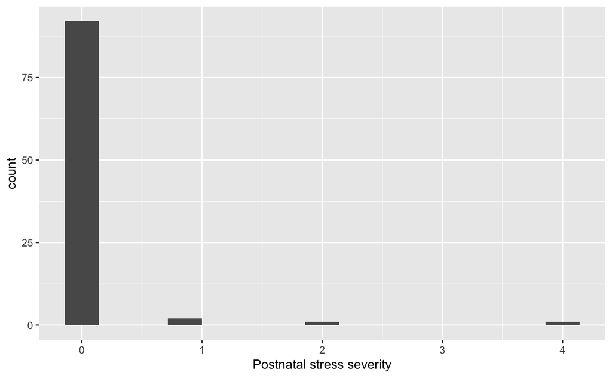

```r
lscr_T1lg_6mocs %>%
  ggplot(aes(sum_sev_postnatal)) +
  geom_histogram(bins = 15) +
  labs(x = "Postnatal stress severity")
```